# Projekt Inteligencja Obliczeniowa

### Rodzaj sądziedztwa

Poniżej zbadany został wpływ rodzaju sasiedztwa na długość ścieżki:

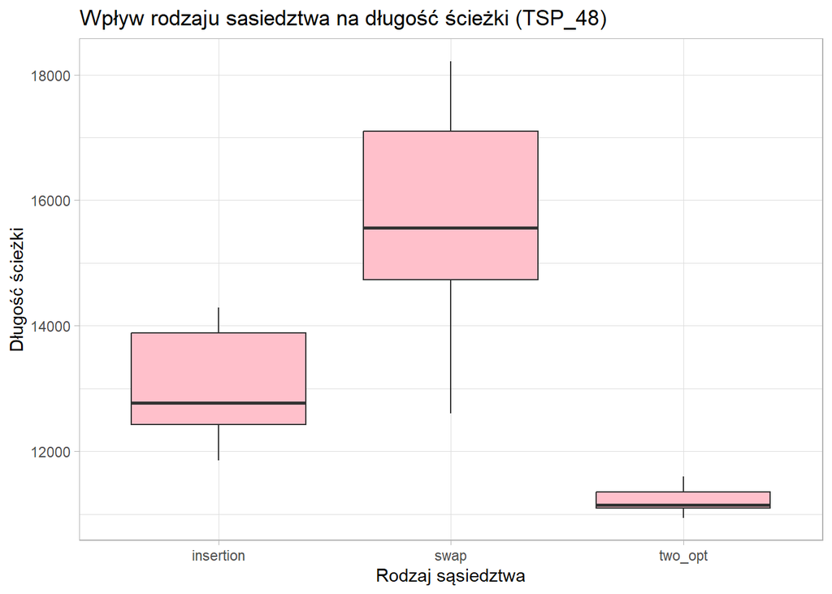

**Statystyki długości ścieżki w zależności od rodzaju sąsiedztwa (TSP_48)**

| PARAMETR | Min | Max | Mean |
| --- | --- | --- | --- |
| insertion | 11856 | 14291 | 13056.7 |
| swap | 12603 | 18216 | 15767.7 |
| two_opt | 10941 | 11601 | 11217.2 |

Pojawiła nam się tutaj również zależność pomiędzy rodzajem sąsiedztwa, a medianą i średnią długością ścieżki. Najlepsze wyniki uzyskiwane są dla rodzaju sąsiedtwa `2-opt`, a najgorsze dla `swap`. Wyniki dla `2-opt` charakteryzują się małą wariancją (rozkład jest wąski), co wskazuje na niewielkie różnice w długościach ścieżek.

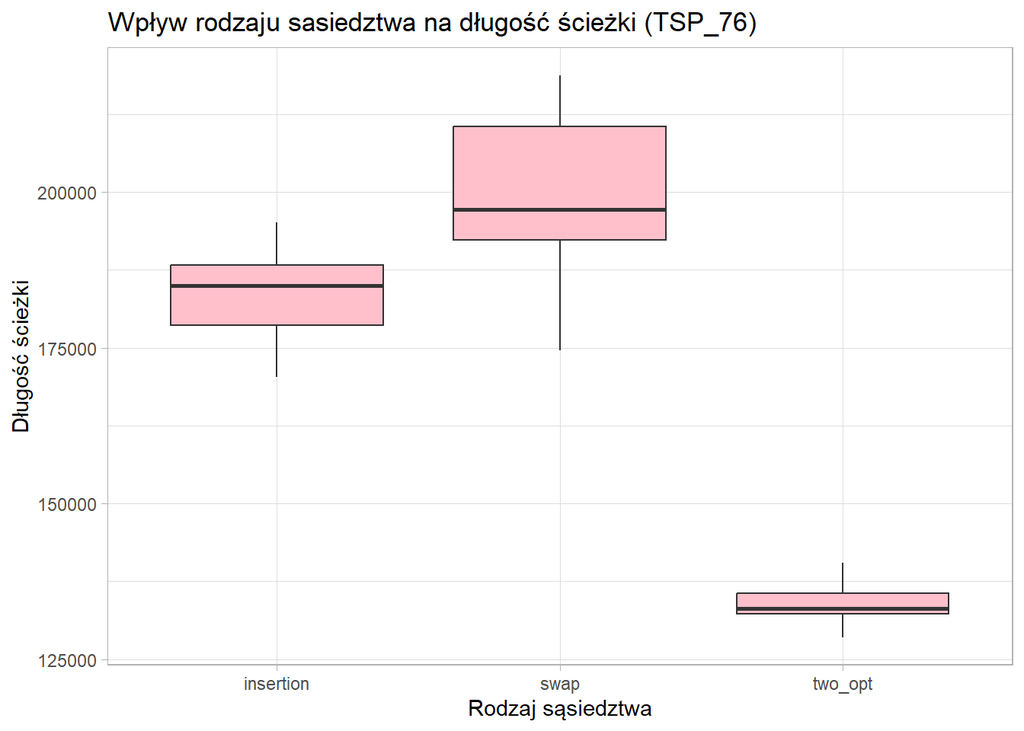

**Statystyki długości ścieżki w zależności od rodzaju sąsiedztwa (TSP_76)**

| PARAMETR | Min | Max | Mean |
| --- | --- | --- | --- |
| insertion | 170264.9 | 195182.6 | 183609.6 |
| swap | 174582.6 | 218781.9 | 199075.4 |
| two_opt | 128558.9 | 140486.3 | 133767.5 |

Dla TSP_76 mamy podobną sytuację. Wyniki są najlepsze dla `2-opt`, najgorsze dla `swap`. Podobna jest też sytuacja z wariancją dla `2-opt`. Nie ma tam takiej różnorodności jak w pozostałych.

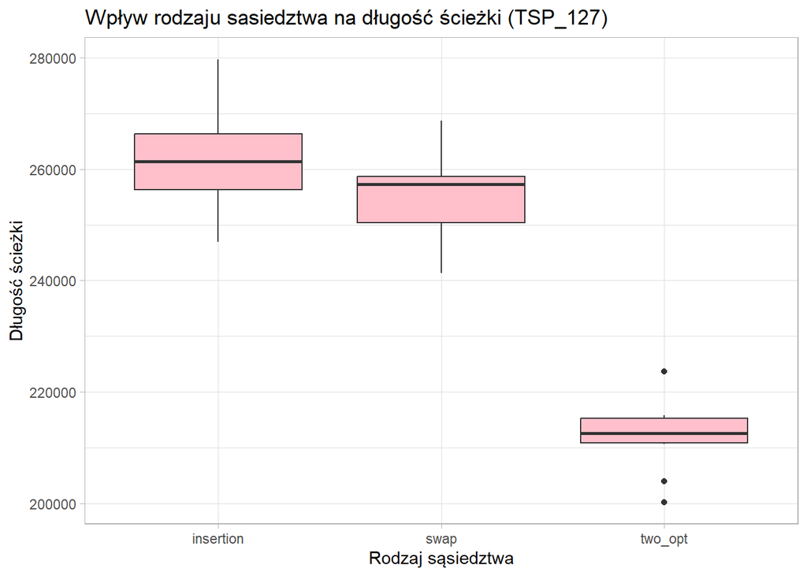

**Statystyki długości ścieżki w zależności od rodzaju sąsiedztwa (TSP_127)**

| PARAMETR | Min | Max | Mean |
| --- | --- | --- | --- |
| insertion | 246902.1 | 279693.8 | 262145.7 |
| swap | 241355.2 | 268701.8 | 254681.7 |
| two_opt | 200281.5 | 223668.5 | 212065.5 |

### Długość listy tabu

Poniżej zbadany został wpływ długości listy tabu na długość ścieżki:

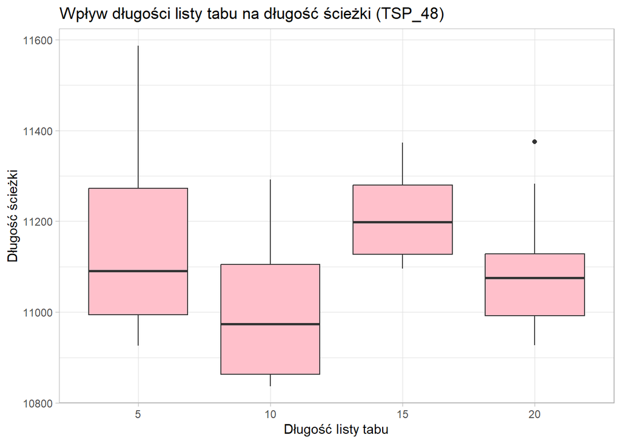

**Statystyki długości ścieżki w zależności od długości listy tabu (TSP_48)**

| PARAMETR | Min | Max | Mean |
| --- | --- | --- | --- |
| 5 | 10926 | 11587 | 11156.8 |
| 10 | 10837 | 11292 | 11003.5 |
| 15 | 11096 | 11373 | 11210.7 |
| 20 | 10927 | 11375 | 11096.2 |

Mediana i średnia długości ścieżki na początku maleje, ale później znowu rośnie. W przypadku TSP_48 liczaba miast jest stosunkowo mała, więc przy zbyt długiej liście tabu algorytm może zabraniać zbyt wiele rozwiązań. Dlatego w w przypadku długości listy tabu = 15 i 20, średnie i mediana są wyższe niż dla długości listy = 10. Natomiast 5 może być zbyt małą liczbą i algorytm nie zapamiętuje wystarczającej liczby ostatnich ruchów, co oznacza, że łatwo może powrócić do wcześniej odwiedzonych rozwiązań.

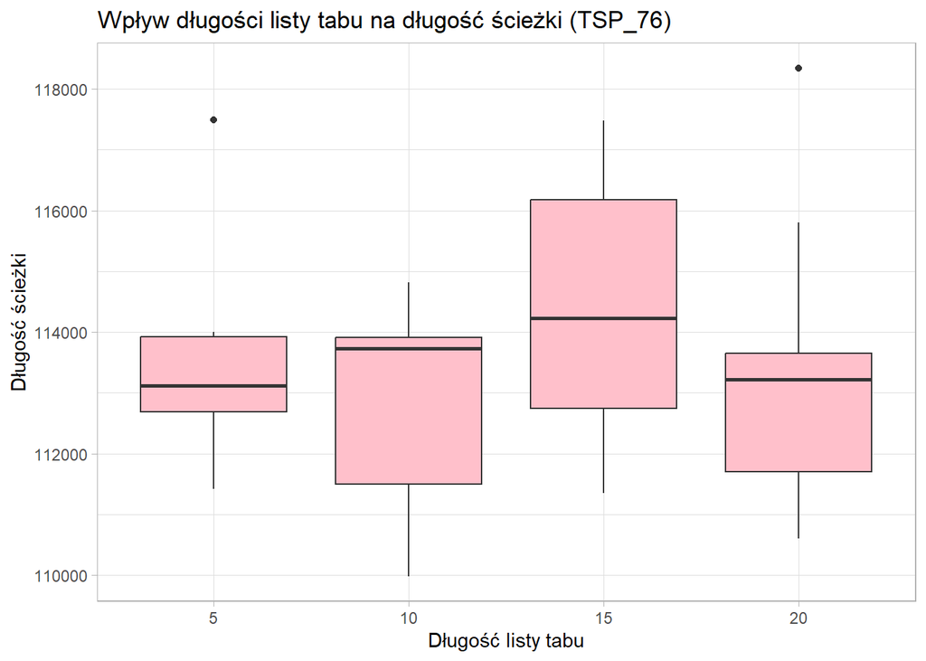

**Statystyki długości ścieżki w zależności od długości listy tabu (TSP_76)**

| PARAMETR | Min | Max | Mean |
| --- | --- | --- | --- |
| 5 | 111415.4 | 117489.9 | 113469.1 |
| 10 | 109983.6 | 114818.3 | 112902.9 |
| 15 | 111346.3 | 117473.5 | 114343.2 |
| 20 | 110597.7 | 118344.4 | 113376.7 |

Dla TSP_76 ciężko wyciągnąć jakąś zależność z wykresów. Mediana i średnia się wahają. Nie sprawdzają się tutaj poprzednie wyjaśnienia. Może należałoby sprawdzić więcej wartości tego parametru w tym przypadku.

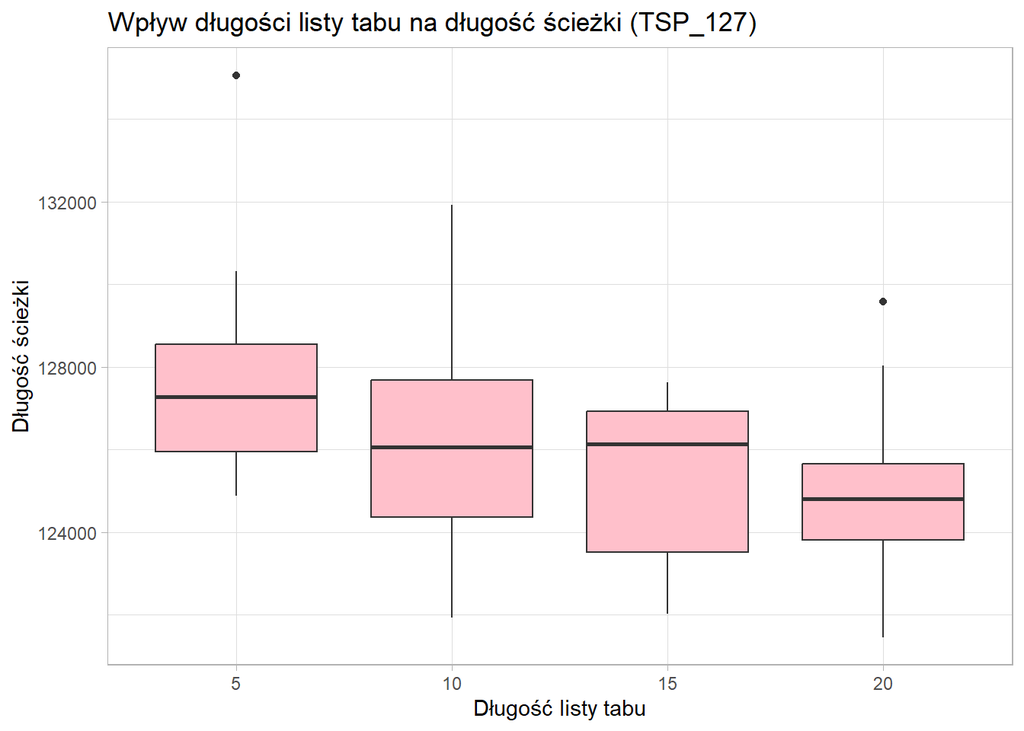

**Statystyki długości ścieżki w zależności od długości listy tabu (TSP_127)**

| PARAMETR | Min | Max | Mean |
| --- | --- | --- | --- |
| 5 | 124887.1 | 135062.4 | 127889.3 |
| 10 | 121926.8 | 131919.6 | 126189.8 |
| 15 | 122022.9 | 127618.8 | 125331.0 |
| 20 | 121462.2 | 129589.6 | 124972.3 |

Natomiast dla TSP_127 widać dobrze, że wraz ze wzrostem długości listy, maleje średnia i mediana długości ścieżki. Przy tak dużej liczbie miast (127), mała lista tabu nie spełnia dobrze swojej roli i często algorytm wraca do rozwiązań już odwiedzonych.

Pojawia się tu pewna zależność między długością listy tabu a długością ścieżki. Jednak dużo też zależy od liczby miast w problemie komiwojażera. Od niej powinna być uzależniona długość listy tabu. Dla TSP_48 można byłby sprawdzić więcej wartości tego parametru, może wtedy ta zależność byłaby tam bardziej widoczna. Natomiast ciekawy przypadek jest dla TSP_76. Ciężko tam stwierdzić, aby jakakolwiek zależność istniała.

### Liczba iteracji

Poniżej zbadany został wpływ liczby iteracji na długość ścieżki:

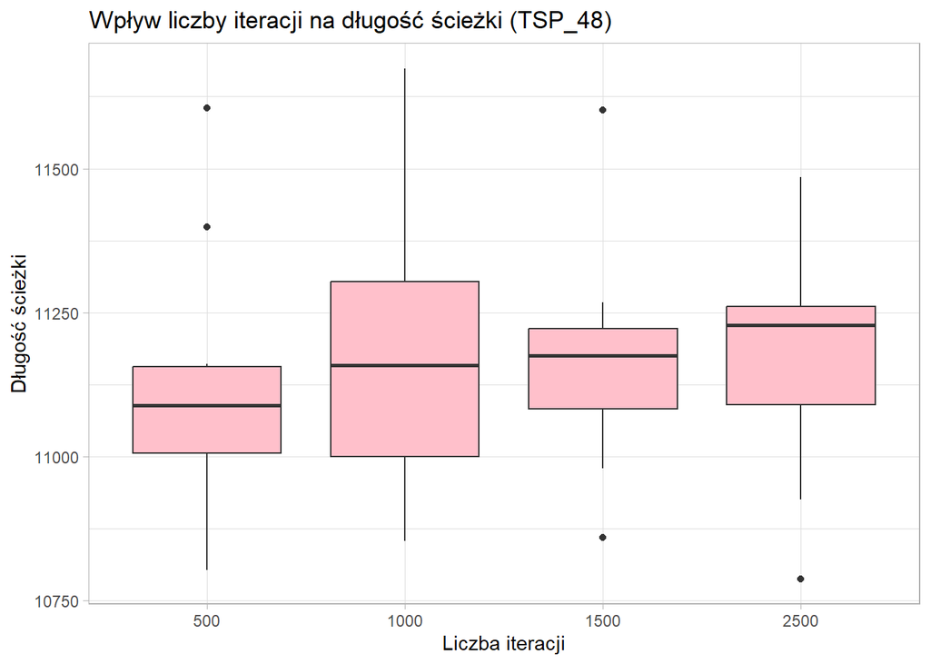

**Statystyki długości ścieżki w zależności od liczby iteracji (TSP_48)**

| PARAMETR | Min | Max | Mean |
| --- | --- | --- | --- |
| 500 | 10803 | 11605 | 11132.3 |
| 1000 | 10854 | 11674 | 11182.9 |
| 1500 | 10860 | 11601 | 11165.2 |
| 2500 | 10788 | 11485 | 11167.8 |

W przypadku liczby iteracji pojawiła się ciekawa sytuacja. Mediana długości ścieżki rośnie wraz z liczbą iteracji. Średnia natomiast wzrosła w odniesieniu do liczby iteracji = 500. Spodziewalibyśmy się raczej odwrotnej sytuacji. Niezależnie od wartości parametru, w każdym przypadku minimalna wartość jest niższa od tej uzyskanej przez Solver (10868). Średnie są natomiast zbliżone.

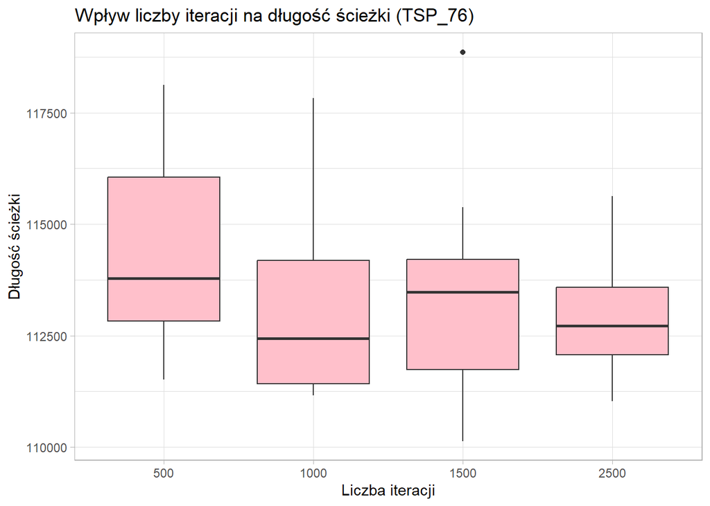

**Statystyki długości ścieżki w zależności od liczby iteracji (TSP_76)**

| PARAMETR | Min | Max | Mean |
| --- | --- | --- | --- |
| 500 | 111514.2 | 118124.2 | 114323.8 |
| 1000 | 111163.3 | 117822.9 | 113194.3 |
| 1500 | 110137.5 | 118858.6 | 113360.6 |
| 2500 | 111032.0 | 115632.3 | 112910.2 |

W tym przypadku natomiast średnia zmalała i mediana również w odniesieniu do liczby iteracji = 500. Pojawiła się odwrotna sytuacja niż dla TSP_48. Wyniki są zdecydowanie lepsze niż te uzyskane przez Solver (118293.5). Średnia również zdecydowanie zmalała.

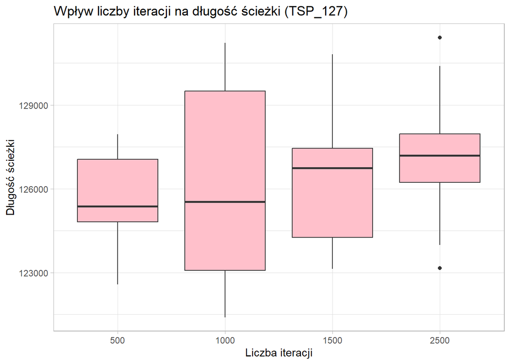

**Statystyki długości ścieżki w zależności od liczby iteracji (TSP_127)**

| PARAMETR | Min | Max | Mean |
| --- | --- | --- | --- |
| 500 | 122575.0 | 127954.0 | 125697.2 |
| 1000 | 121398.3 | 131230.0 | 126090.5 |
| 1500 | 123137.2 | 130815.6 | 126578.6 |
| 2500 | 123163.6 | 131420.7 | 127180.3 |

Tutaj pojawia się podobna zależność co w przypadku TSP_48. Średnia i mediana rosną w porównaniu do tych uzyskanych dla liczby iteracji = 500. Jednak wyniki również w tym przypadku są zdecydowanie lepsze niż te uzyskane przez Solver(140217.6).

Ciężko więc stwierdzić, czy występuje tu jakaś zależność. W 2/3 przypadków wzrost liczby iteracji powodują wzrost średniej i mediany.

### Liczba iteracji bez poprawy

Poniżej zbadany został wpływ liczby iteracji bez poprawy na długość ścieżki:

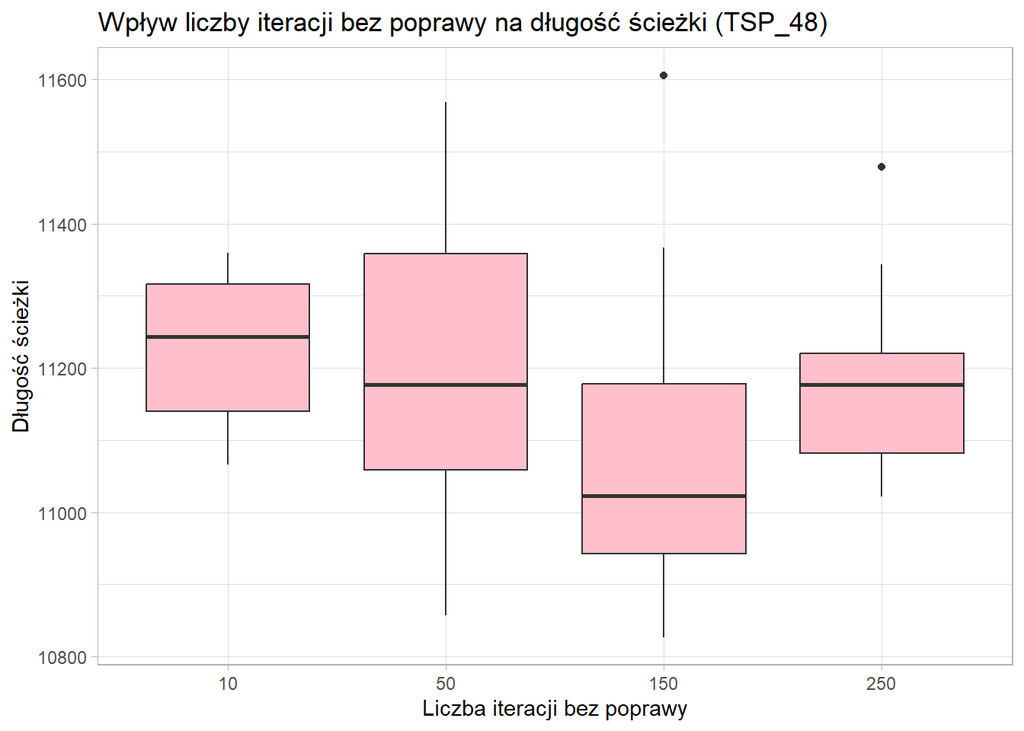

**Statystyki długości ścieżki w zależności od liczby iteracji bez poprawy (TSP_48)**

| PARAMETR | Min | Max | Mean |
| --- | --- | --- | --- |
| 10 | 11066 | 11360 | 11228.3 |
| 50 | 10857 | 11569 | 11213.7 |
| 150 | 10827 | 11606 | 11099.5 |
| 250 | 11022 | 11479 | 11186.6 |

Na początku widać, że mediana i średnia długości ścieżki maleją znacząco. Później jednak następuję wzrost tych statystyk. Przy zwiększaniu liczby iteracji bez poprawy, algorytm ma więcej czasu na eksplorację, co pozwala mu unikać lokalnych minimów i znajdować lepsze rozwiązania. Jednak zbyt duże wartości powodują, że algorytm zaczyna eksplorować przestrzeń rozwiązań zbyt długo, nawet w sytuacjach, gdy lepsze rozwiązania już się nie pojawiają, stąd wzrost średniej i mediany.

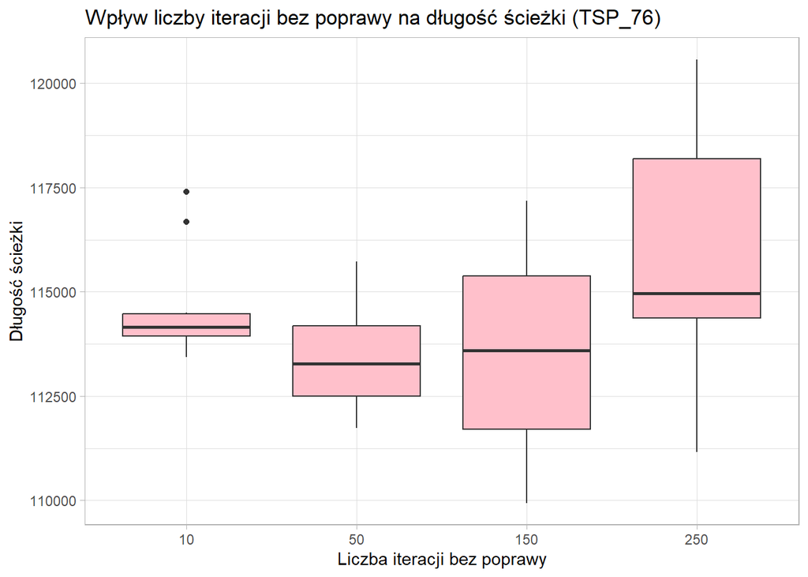

**Statystyki długości ścieżki w zależności od liczby iteracji bez poprawy (TSP_76)**

| PARAMETR | Min | Max | Mean |
| --- | --- | --- | --- |
| 10 | 113435.8 | 117398.8 | 114653.2 |
| 50 | 111733.3 | 115725.0 | 113419.5 |
| 150 | 109939.4 | 117181.3 | 113441.7 |
| 250 | 111160.0 | 120571.4 | 115683.3 |

Sytaucja jest tutaj podobna. Jednak już przy liczbie iteracji bez poprawy = 150 mamy wzrost mediany i średniej. Dla TSP_76 już od tej wartości algorytm może zbyt długo poszukiwać lepszego rozwiązania.

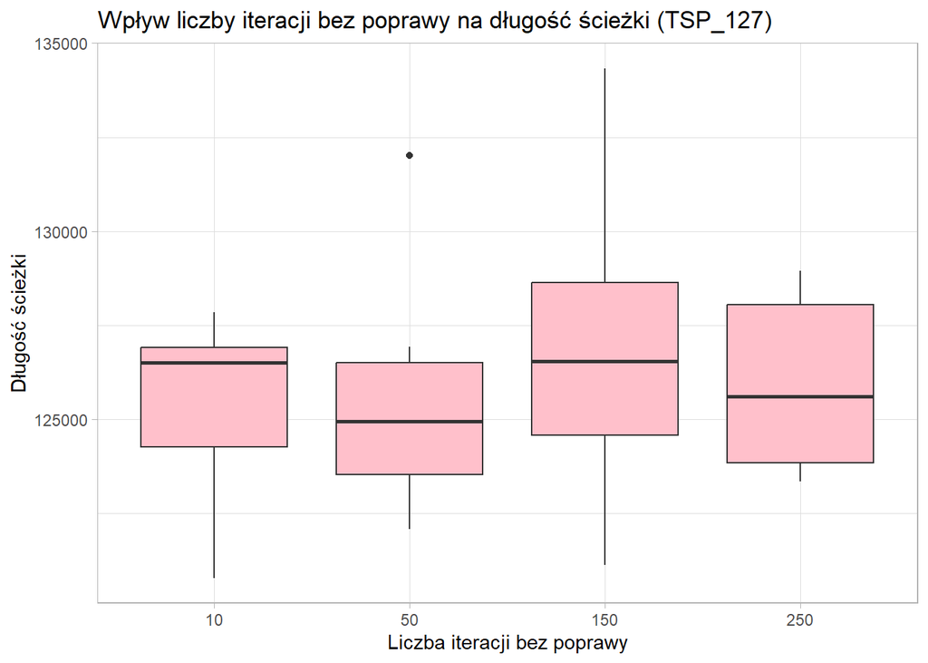

**Statystyki długości ścieżki w zależności od liczby iteracji bez poprawy (TSP_127)**

| PARAMETR | Min | Max | Mean |
| --- | --- | --- | --- |
| 10 | 120791.7 | 127846.5 | 125366.5 |
| 50 | 122088.6 | 132018.2 | 125362.7 |
| 150 | 121124.3 | 134333.7 | 126862.2 |
| 250 | 123361.5 | 128953.9 | 125921.4 |

Tutaj sytuacja jest cięższa do zdefiniowania. Mediana raz maleje, raz rośnie. Natomiast średnia utrzymuje się na podobnym poziomie. Otrzymane wyniki są zdecydowanie lepsze.

Można więc powiedzieć, że trzeba odpowiednio dostosować liczbę iteracji bez poprawy. Zbyt mała liczba może spowodować, że algorytm nie będzie eksplorował dostatecznie głęboko przestrzeni rozwiązań i szybko zatrzyma się na minimach lokalnych. Natomiast zbyt duża liczba iteracji bez poprawy może spowodować, że algorytm przejdzie przez wiele słabszych rozwiązań i poświęci zbyt dużo czasu na mniej obiecujące rozwiązania.

### Limit czasowy

Poniżej zbadany został wpływ limitu czasowego na długość ścieżki:

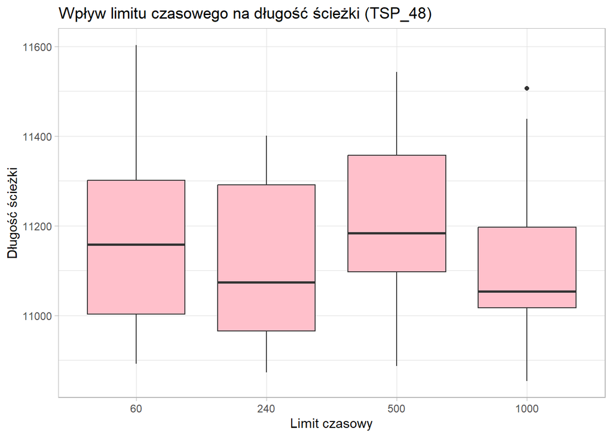

**Statystyki długości ścieżki w zależności od limitu czasowego (TSP_48)**

| PARAMETR | Min | Max | Mean |
| --- | --- | --- | --- |
| 60 | 10892 | 11603 | 11173.0 |
| 240 | 10873 | 11401 | 11117.7 |
| 500 | 10887 | 11543 | 11215.8 |
| 1000 | 10854 | 11506 | 11130.2 |

Mediana oraz średnia się wahają. Nie widać tu zależności limitu czasu od długości ścieżki. Wyniki natomiast są zbliżone do tych z Solvera.

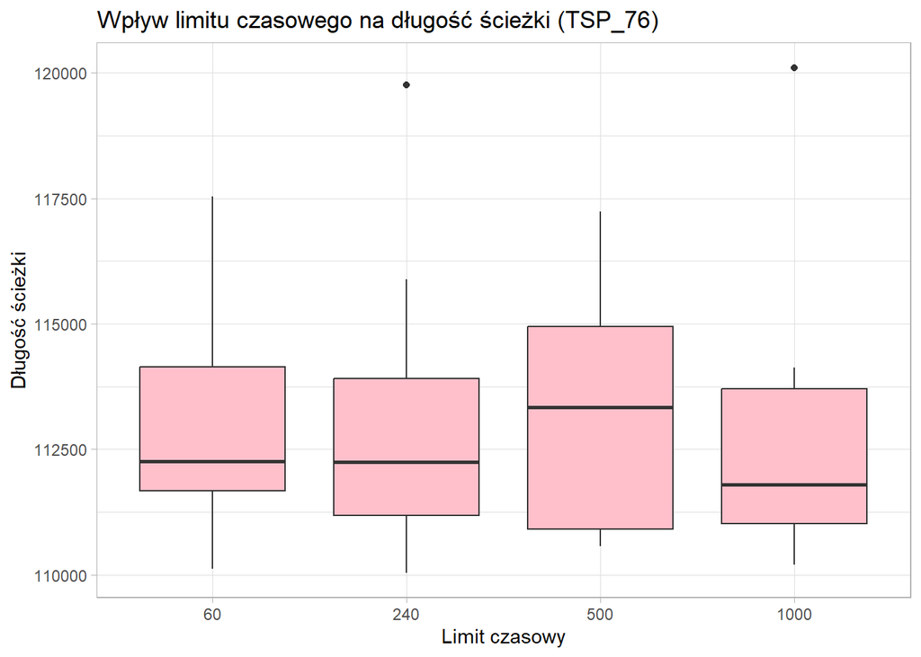

**Statystyki długości ścieżki w zależności od limitu czasowego (TSP_76)**

| PARAMETR | Min | Max | Mean |
| --- | --- | --- | --- |
| 60 | 110115.8 | 117537.5 | 113130.9 |
| 240 | 110041.2 | 119755.5 | 113056.1 |
| 500 | 110562.3 | 117240.7 | 113331.1 |
| 1000 | 110202.7 | 120104.4 | 112822.9 |

Tutaj podobna sytuacja. Średnia i mediana raz rosną, raz maleją.

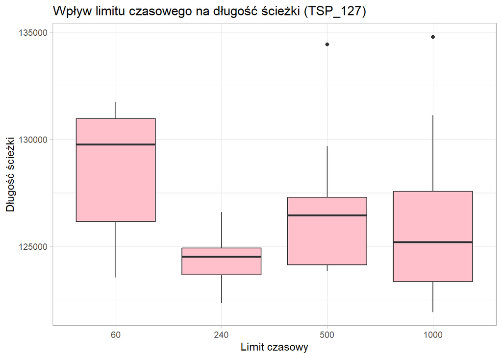

**Statystyki długości ścieżki w zależności od limitu czasowego (TSP_127)**

| PARAMETR | Min | Max | Mean |
| --- | --- | --- | --- |
| 60 | 123533.2 | 131746.5 | 128526.0 |
| 240 | 122336.3 | 126589.3 | 124320.2 |
| 500 | 123836.8 | 134436.9 | 126776.1 |
| 1000 | 121926.2 | 134788.0 | 126249.5 |

Dla TSP_127 na początku widać duży spadek wartości mediany i średniej. Nie było to w widoczne w poprzednich TSP w takim stopniu. Może to się wiązać z tym, że TSP_127 ma największą liczbę miast, więc limit czasowy = 60s był zbyt mały dla niego.

Nie widać tutaj żadnej zależności długości ścieżki od limitu czasu. Jedynie dla TSP_127 pojawiła się bardziej znacząca różnica w odniesieniu do początkowego limitu.

## Podsumowanie

Najlepsze wyniki dla **TSP_48** przy zmianie poszczególnych parametrów:

- `Klasyczne` - 10851.0
- `Rodzaj sąsiedztwa` - 10941 (rodzaj sąsiedztwa - 2-opt)
- `Długość listy tabu` - 10837 (długość listy tabu - 10)
- `Liczba iteracji` - 10788 (liczba iteracji - 2500)
- `Liczba iteracji bez poprawy` - 10827 (liczba iteracji bez poprawy - 150)
- `Limit czasu` - 10854 (limit czasu - 1000)

Dla TSP_48 przy użyciu algorytmu tabu search udało się uzyskać parę lepszych wyników niż ten uzyskany przez Solver (10868).

Najlepsze wyniki dla **TSP_76** przy zmianie poszczególnych parametrów:

- `Klasyczne` - 129754.0
- `Rodzaj sąsiedztwa` - 128558.9 (rodzaj sąsiedztwa - 2-opt)
- `Długość listy tabu` - 109983.6 (długość listy tabu - 10)
- `Liczba iteracji` - 110137.5 (liczba iteracji - 1500)
- `Liczba iteracji bez poprawy` - 109939.4 (liczba iteracji bez poprawy - 150)
- `Limit czasu` - 110041.2 (limit czasu - 240)

Dla TSP_76 przy użyciu algorytmu tabu search również udało się uzyskać kilka lepszych wyników niż ten uzyskany przez Solver (118293.5).

Najlepsze wyniki dla **TSP_127** przy zmianie poszczególnych parametrów:

- `Klasyczne` - 204850.2
- `Rodzaj sąsiedztwa` - 200281.5 (rodzaj sąsiedztwa - 2-opt)
- `Długość listy tabu` - 121462.2 (długość listy tabu - 20)
- `Liczba iteracji` - 121398.3 (liczba iteracji - 1000)
- `Liczba iteracji bez poprawy` - 120791.7 (liczba iteracji bez poprawy - 10)
- `Limit czasu` - 121926.2 (limit czasu - 1000)

Dla TSP_127 przy użyciu algorytmu tabu search udało się uzyskać lepsze wyniki niż ten uzyskany przez Solver (140217.6).

# Algorytm genetyczny (GA)

**Algorytm genetyczny** (ang. Genetic Algorithm, GA) to technika optymalizacyjna, która przeszukuje przestrzeń możliwych rozwiązań danego problemu, wykorzystując elementy losowe w celu znalezienia najlepszego rozwiązania. Jego działanie naśladuje proces ewolucji biologicznej. Początkowa populacja rozwiązań poddawana jest serii operacji, takich jak krzyżowanie oraz mutacje, co prowadzi do powstania nowej generacji. Proces ten jest powtarzany wielokrotnie, aż do osiągnięcia określonej liczby iteracji lub spełnienia innych warunków stopu.

Zasada działania algorytmu genetycznego do rozwiązania problemu komiwojażera:

1. Na początku inicjalizowana jest populacja z losowymi permutacjami.
2. Wybór osobników do krzyżowania odbywa się na podstawie jednej z metod selekcji: turniejowej lub ruletki, które przydzielają większą szansę na wybór osobnikom o lepszym dopasowaniu.
3. Algorytm tworzy nowe rozwiązania (dzieci) przez krzyżowanie par rodziców za pomocą jednej z metod: order lub PMX.
4. Mutacja jest wykonywana zgodnie z wybranym typem.
5. Po każdym pokoleniu algorytm ocenia rozwiązania, wybierając najlepsze na podstawie minimalnej odległości (kosztu trasy).
6. Algorytm powtarza proces selekcji, krzyżowania i mutacji przez wiele pokoleń, stale dążąc do poprawy wyników, aż osiągnie ustaloną liczbę pokoleń lub osiągnie optymalne rozwiązanie.

## Badane parametry

W ramach algorytmu genetycznego badane są następujące parametry:

- **`population_size`** - wielkość populacji - liczba osobników w populacji, które będą brane pod uwagę w danej iteracji algorytmu
- **`mutation_rate`** - prawdopodobieństwo mutacji - prawdopodobieństwo z jakim nastąpi mutacja genów w osobnikach
- **`crossover_rate`** - prawdopodobieństwo krzyżowania - prawdopodobieństwo z jakim nastąpi krzyżowanie osobników w populacji
- **`selection_method`** - metoda doboru rodziców - sposób wyboru najlepszych osobników do reprodukcji:
  - `tournament` - metoda turniejowa - losowo wybierane jest k osobników z populacji. Następnie spośród nich wybierany jest osobnik o najlepszym wyniku.
  - `roulette` - metoda ruletki - każdemu osobnikowi w populacji przydzielane jest prawdopodobieństwo wyboru proporcjonalne do jego wyniku. Następnie, losowana jest liczba z przedziału [0, 1], a na jej podstawie wybierany jest osobnik: im większe prawdopodobieństwo, tym większa szansa, że jego wynik odpowiada wylosowanej liczbie
- **`crossover_method`** - metoda krzyżowania - sposób łączenia genów (tras) rodziców w celu stworzenia potomków:
  - `order` - z pierwszego rodzica wybierany jest losowy segment miast, który jest kopiowany do potomka w to samo miejsce, pozostałe miasta są uzupełniane w potomku zgodnie z ich kolejnością wystąpienia w drugim rodzicu
  - `pmx` - dziedziczenie części trasy od każdego z rodziców przy zachowaniu oryginalnej kolejności odwiedzonych miast, jednocześnie eliminując duplikaty w nowo powstałym rozwiązaniu
- **`generations`** - liczba pokoleń, czyli liczba iteracji algorytmu
- **`mutation_method`** - metoda mutacji - metoda generowania nowych rozwiązań na podstawie aktualnego rozwiązania. W badaniu uwzględniono typy:
  - `swap` nowe rozwiązanie powstaje poprzez zamianę miejscami dwóch genów w bieżącej permutacji trasy
  - `insertion` polega na wyborze jednego genu z danej permutacji, usunięciu go z jego pierwotnej pozycji, a następnie wstawieniu go w inne, wybrane miejsce w tej samej permutacji
  - `inversion` odwrócenie kolejności genów w wybranym segmencie permutacji

### Klasyczne

Za podstawowe dane przyjmujemy:

- population_size = 10
- generations = 5000
- crossover_rate = 0.6
- mutation_rate = 0.15
- selection_method = `tournament`
- crossover_method = `order`
- mutation_method = `2-opt`

| TSP_48 | TSP_76 | TSP_127 |
| --- | --- | --- |
| 11066 | 124301.1 | 165047.0 |
| 11668 | 125818.0 | 169116.2 |
| 11789 | 133834.7 | 185343.3 |
| 11084 | 140042.7 | 174967.2 |
| 11297 | 125535.7 | 165263.1 |
| 11612 | 130204.8 | 169098.3 |
| 11630 | 127466.2 | 167056.3 |
| 11419 | 132770.0 | 174114.1 |
| 12028 | 116714.4 | 171030.4 |
| 11048 | 129846.3 | 170132.2 |

|  | Min | Max | Mean |
| --- | --- | --- | --- |
| TSP_48 | 11048.0 | 12028.0 | 11464.1 |
| TSP_76 | 116714.4 | 140042.7 | 128653.4 |
| TSP_127 | 165047.0 | 185343.3 | 171116.8 |

**Czas**

|  | Min | Max | Mean |
| --- | --- | --- | --- |
| TSP_48 | 0.9281752 | 1.721040 | 1.268607 |
| TSP_76 | 2.5611053 | 3.303076 | 2.975398 |
| TSP_127 | 5.4239855 | 6.417854 | 5.750039 |

Średnie czasy dla każdego z przypadków są bardzo niskie.

### Wielkość populacji

Poniżej zbadany został wpływ wielkości populacji na długość ścieżki:

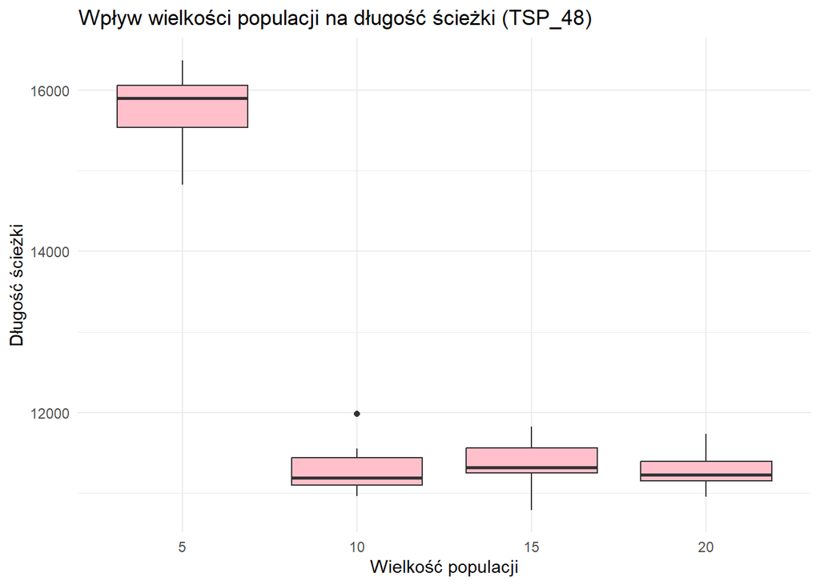

**Statystyki długości ścieżki w zależności od wielkości populacji (TSP_48)**

| PARAMETR | Min | Max | Mean |
| --- | --- | --- | --- |
| 5 | 14825 | 16370 | 15756.9 |
| 10 | 10962 | 11984 | 11295.3 |
| 15 | 10795 | 11827 | 11364.7 |
| 20 | 10956 | 11734 | 11282.3 |

Średnia i mediana dla wielkości populacji = 5 są zdecydowanie wyższe niż w pozostałych przypadkach. Dla innych parametrów utrzymują się na podobnym poziomie.

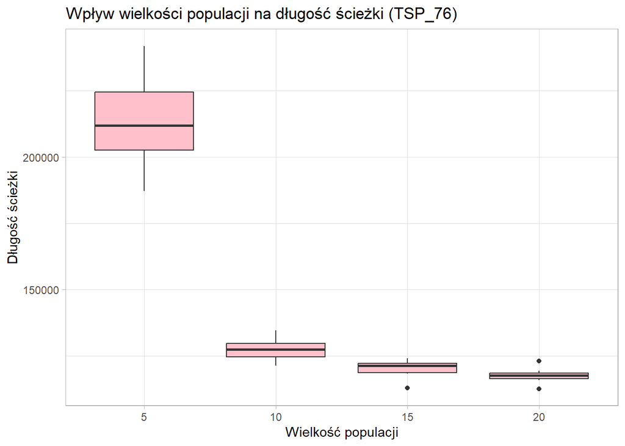

**Statystyki długości ścieżki w zależności od wielkości populacji (TSP_76)**

| PARAMETR | Min | Max | Mean |
| --- | --- | --- | --- |
| 5 | 187171.1 | 241956.7 | 213355.0 |
| 10 | 121201.7 | 134551.0 | 127368.3 |
| 15 | 112905.7 | 124142.9 | 120237.5 |
| 20 | 112600.5 | 123092.0 | 117637.7 |

Dla TSP_76 dla parametru = 5 średnia i mediana są również największe w porównaniu do pozostałych wyników. Natępnie widać, że wraz ze wzrostem liczby populacji, maleje średnia i mediana.

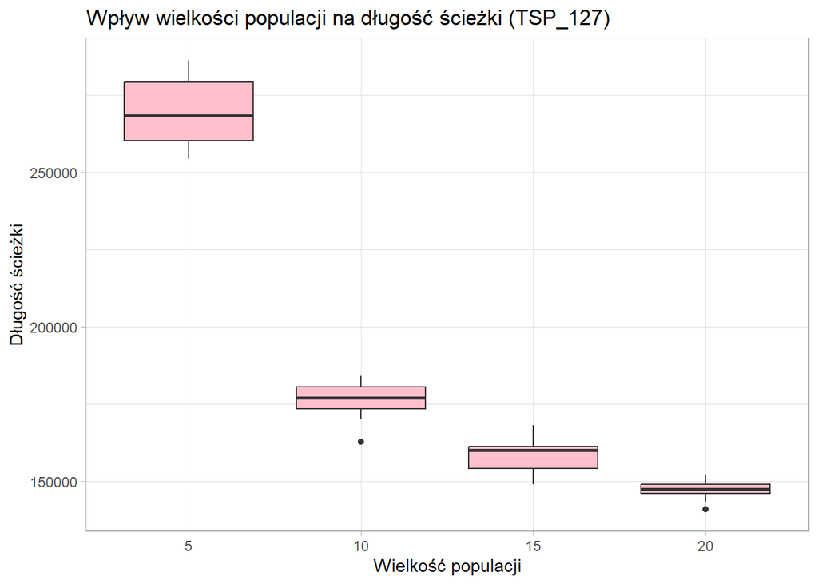

**Statystyki długości ścieżki w zależności od wielkości populacji (TSP_127)**

| PARAMETR | Min | Max | Mean |
| --- | --- | --- | --- |
| 5 | 254294.8 | 286335.9 | 269627.5 |
| 10 | 162804.2 | 184122.1 | 176082.3 |
| 15 | 148999.2 | 168262.0 | 158469.8 |
| 20 | 141116.7 | 152309.5 | 147394.4 |

Tutaj pojawia się analogiczna sytuacja jak dla TSP_76. Gdy zwiększyła się liczba miast, bardziej widoczna stała się zależność, że wraz ze wzrostem liczby populacji, maleje średnia i mediana długości ścieżki.

Liczba populacji = 5 w każdym z przypadków dała najwyższe długości ścieżki. Natomiast wraz ze wzrostem parametru, maleje długość ścieżki. Może tak być dlatego, że większa populacja (wieksza liczba osobników w każdej generacji algorytmu) zwiększa różnorodność rozwiązań, co zwiększa szansę na znalezienie lepszego rozwiązania i pozwala uniknąć utknięcia w minimach lokalnych.

### Prawdopodobieństwo mutacji

Poniżej zbadany został wpływ prawdopodobieństwa mutacji na długość ścieżki:

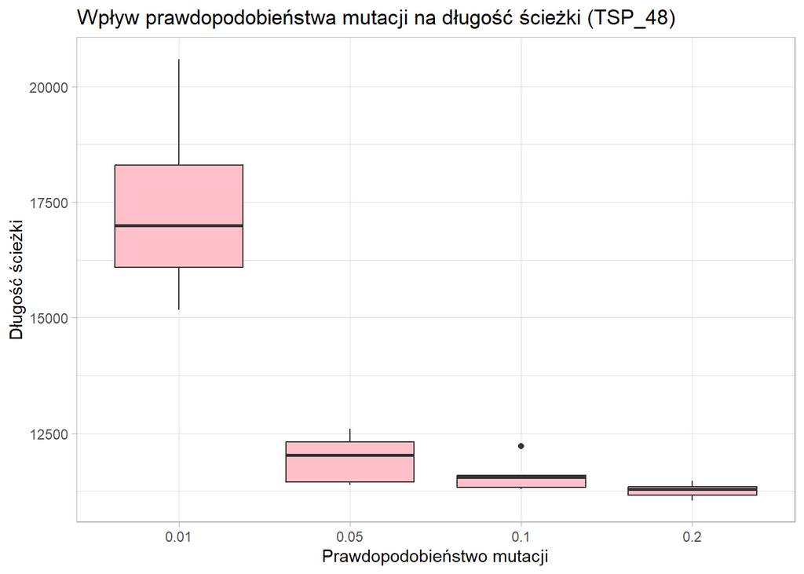

**Statystyki długości ścieżki w zależności od prawdopodobieństwa mutacji (TSP_48)**

| PARAMETR | Min | Max | Mean |
| --- | --- | --- | --- |
| 0.01 | 15167 | 20594 | 17291.6 |
| 0.05 | 11387 | 12594 | 11949.6 |
| 0.10 | 11300 | 12221 | 11542.9 |
| 0.20 | 11055 | 11480 | 11276.6 |

Wraz ze wzrostem prawdopodobieństwa mutacji, maleje średnia i mediana długości ścieżki.

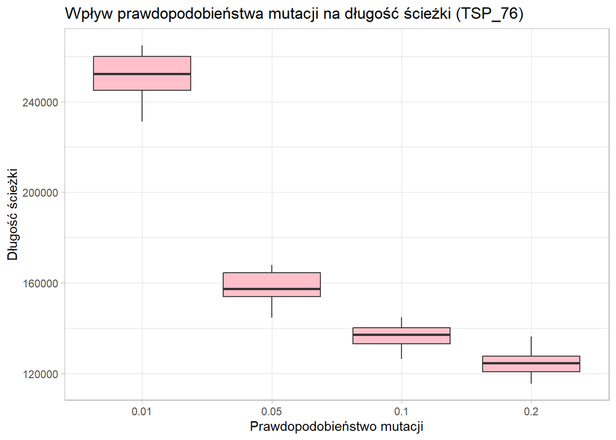

**Statystyki długości ścieżki w zależności od prawdopodobieństwa mutacji (TSP_76)**

| PARAMETR | Min | Max | Mean |
| --- | --- | --- | --- |
| 0.01 | 231229.1 | 264878.9 | 250224.6 |
| 0.05 | 144574.3 | 167924.9 | 158329.3 |
| 0.10 | 126379.0 | 144857.0 | 136289.2 |
| 0.20 | 115561.1 | 136250.3 | 124370.8 |

Dla TSP_76 jest identyczna sytuacja, a nawet bardziej widoczna.

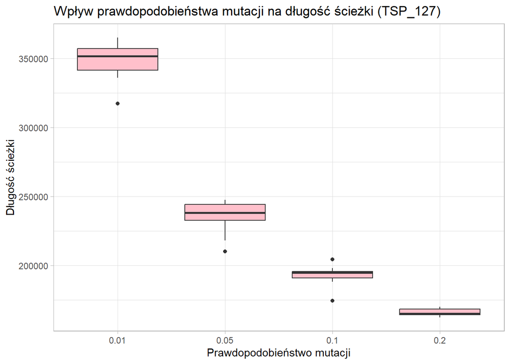

**Statystyki długości ścieżki w zależności od prawdopodobieństwa mutacji (TSP_127)**

| PARAMETR | Min | Max | Mean |
| --- | --- | --- | --- |
| 0.01 | 317266.6 | 365218.7 | 347813.5 |
| 0.05 | 210066.0 | 247427.4 | 235110.6 |
| 0.10 | 174463.8 | 204239.3 | 192795.1 |
| 0.20 | 162368.2 | 170042.5 | 165931.1 |

Analogicznie dla TSP_127. Chociaż średnia w tym przypadku nawet dla parametru = 0.2 jest wyższa niż ta uzyskana w Solverze.

W każdym z przypadków bardzo dobrze widoczna jest zależność, że wraz ze wzrostem prawdopodobieństwa mutacji, maleje długość ścieżki. Mutowanie pozwala na eksplorowanie większej liczby rozwiązań. Niskie wartości parametru powodują, że osobniki w populacji są do siebie dość zbliżone, dlatego długości ścieżki są wtedy większe.

### Prawdopodobieństwo krzyżowania

Poniżej zbadany został wpływ prawdopodobieństwa krzyżowania na długość ścieżki:

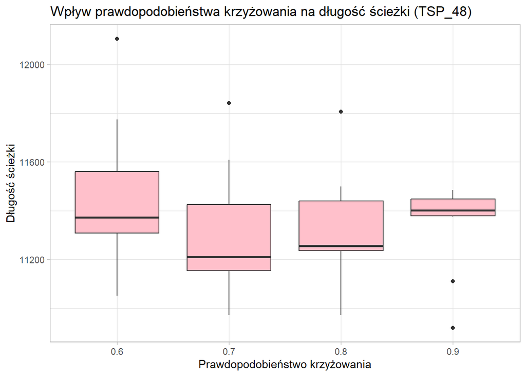

**Statystyki długości ścieżki w zależności od prawdopodobieństwa krzyżowania (TSP_48)**

| PARAMETR | Min | Max | Mean |
| --- | --- | --- | --- |
| 0.6 | 11051 | 12105 | 11461.7 |
| 0.7 | 10972 | 11841 | 11309.8 |
| 0.8 | 10973 | 11805 | 11322.7 |
| 0.9 | 10920 | 11485 | 11341.8 |

Widzimy na początku spadek wartości mediany i średniej. Natomiast później zaczynają delikatnie rosnąć.

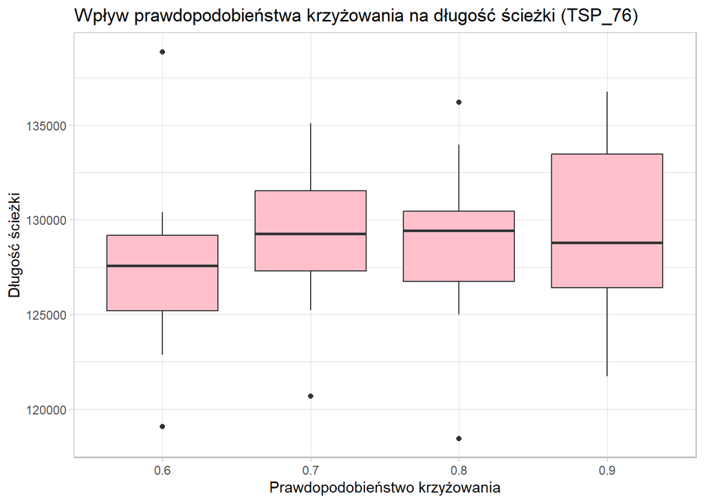

**Statystyki długości ścieżki w zależności od prawdopodobieństwa krzyżowania (TSP_76)**

| PARAMETR | Min | Max | Mean |
| --- | --- | --- | --- |
| 0.6 | 119075.2 | 138879.0 | 127574.0 |
| 0.7 | 120676.8 | 135104.9 | 129081.8 |
| 0.8 | 118452.6 | 136219.0 | 128698.9 |
| 0.9 | 121736.9 | 136773.5 | 129540.2 |

Dla TSP_76 jest już trochę inna sytuacja. Średnia i mediana od początku delikatnie rosną, a później wahają się wokół zbliżonych wartości.

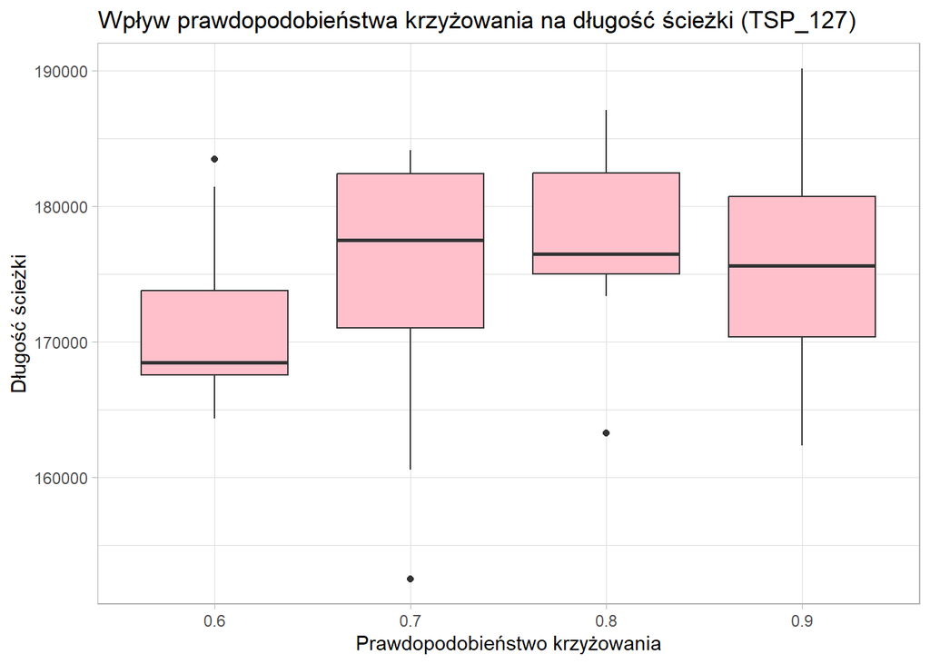

**Statystyki długości ścieżki w zależności od prawdopodobieństwa krzyżowania (TSP_127)**

| PARAMETR | Min | Max | Mean |
| --- | --- | --- | --- |
| 0.6 | 164335.0 | 183448.1 | 171280.6 |
| 0.7 | 152547.3 | 184132.8 | 174338.4 |
| 0.8 | 163269.9 | 187093.1 | 177721.4 |
| 0.9 | 162367.8 | 190148.7 | 175726.6 |

Tutja jest podobona sytaucja jak dla TSP_76.

Ciężko zauważyć tutaj jakąś istotną zależność. Średnie i mediany nie różnią się znacząco.

### Liczba pokoleń

Poniżej zbadany został wpływ liczby pokoleń na długość ścieżki:

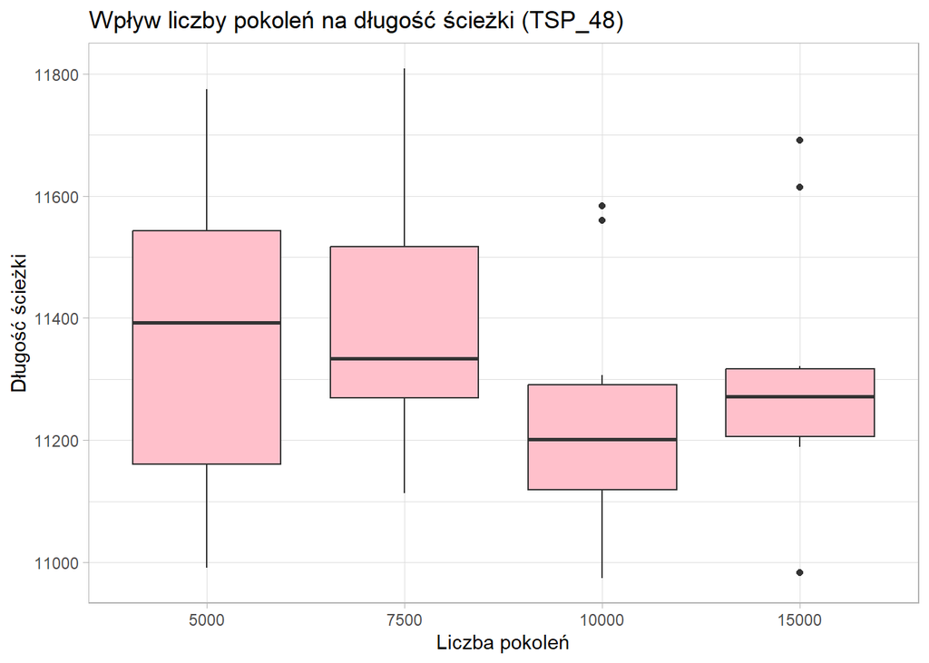

**Statystyki długości ścieżki w zależności od liczby pokoleń (TSP_48)**

| PARAMETR | Min | Max | Mean |
| --- | --- | --- | --- |
| 5000 | 10991 | 11775 | 11368.3 |
| 7500 | 11114 | 11809 | 11395.0 |
| 10000 | 10975 | 11584 | 11237.4 |
| 15000 | 10984 | 11691 | 11305.8 |

Wraz ze wzrostem liczby pokoleń następuje spadek wartości mediany, jednak na końcu ona wzrasta. Średnia natomiast raz rośnie, raz maleje.

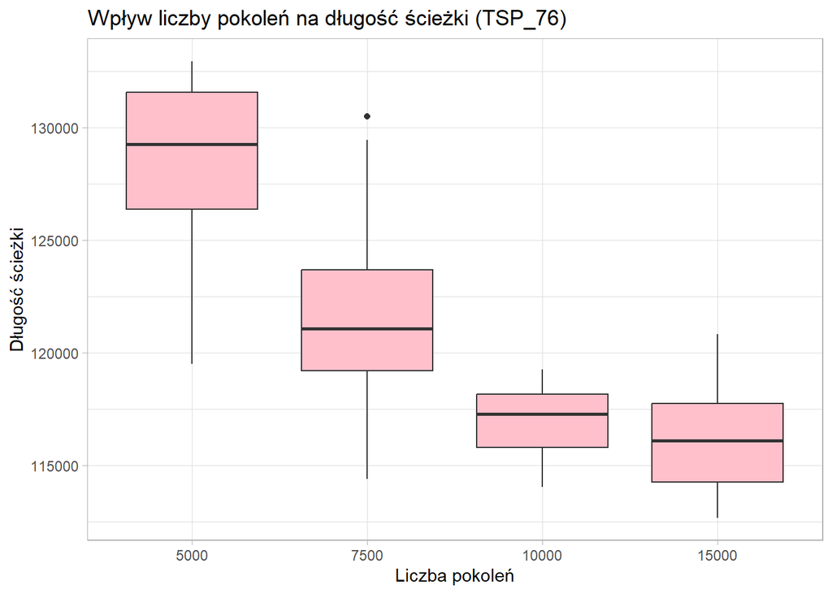

**Statystyki długości ścieżki w zależności od liczby pokoleń (TSP_76)**

| PARAMETR | Min | Max | Mean |
| --- | --- | --- | --- |
| 5000 | 119501.4 | 132944.6 | 128360.5 |
| 7500 | 114391.5 | 130493.6 | 122001.3 |
| 10000 | 114023.7 | 119250.9 | 117007.6 |
| 15000 | 112672.9 | 120819.0 | 116329.0 |

Dla TSP_76 widać, że wraz ze wzrostem liczby pokoleń, maleje zarówno średnia, jak i mediana.

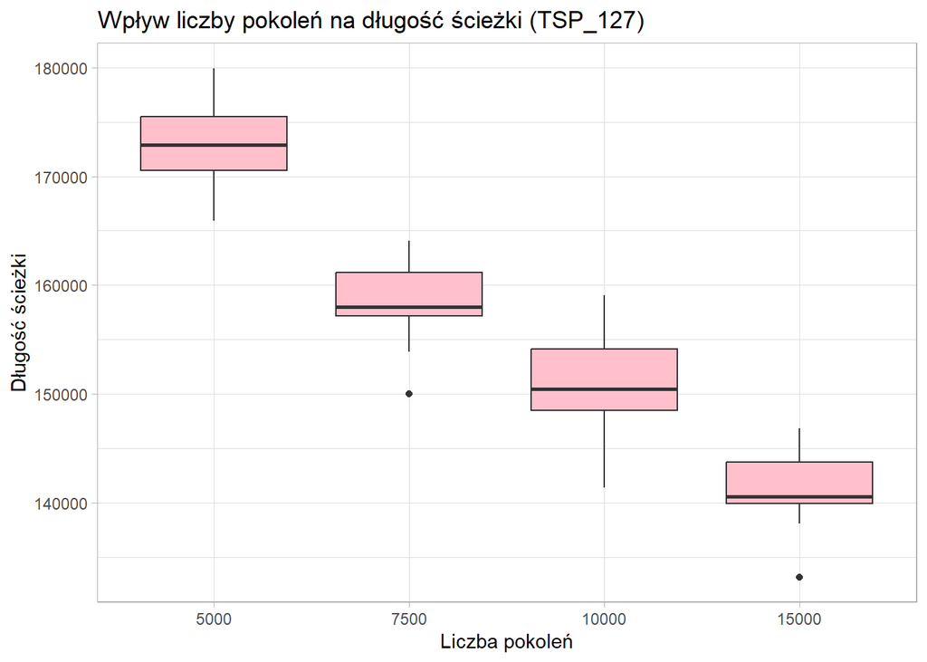

**Statystyki długości ścieżki w zależności od liczby pokoleń (TSP_127)**

| PARAMETR | Min | Max | Mean |
| --- | --- | --- | --- |
| 5000 | 165940.2 | 179956.9 | 173043.8 |
| 7500 | 150007.6 | 164097.1 | 158230.5 |
| 10000 | 141374.5 | 159043.5 | 150904.6 |
| 15000 | 133161.4 | 146846.8 | 141110.3 |

Tutaj pojawia się analogiczna sytuacja, jak dla TSP_76.

Wraz ze wzrostem liczby pokoleń (inaczej liczby iteracji algorytmu), maleje długość ścieżki. Jest to dość logiczna zależność. Większa liczba iteracji zwiększa szanse na dokładne przeszukanie przestrzeni.

### Metoda doboru rodziców

Poniżej zbadany został wpływ metody doboru rodziców na długość ścieżki:

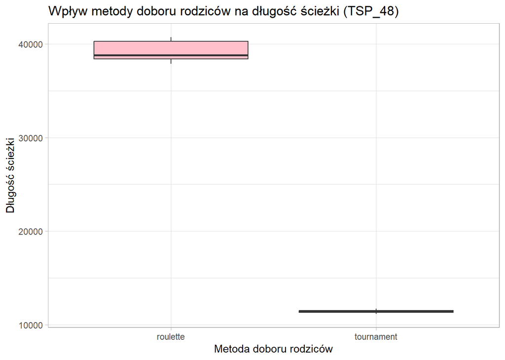

**Statystyki długości ścieżki w zależności od metody doboru rodziców (TSP_48)**

| PARAMETR | Min | Max | Mean |
| --- | --- | --- | --- |
| roulette | 37891 | 40743 | 39185.0 |
| tournament | 11173 | 11702 | 11409.9 |

Dobieranie rodziców metodą ruletki zdecydowanie sie nie sprawdza. Wyniki nawet nie są zbliżone do tych osiągniętych przy metodzie turniejowy.

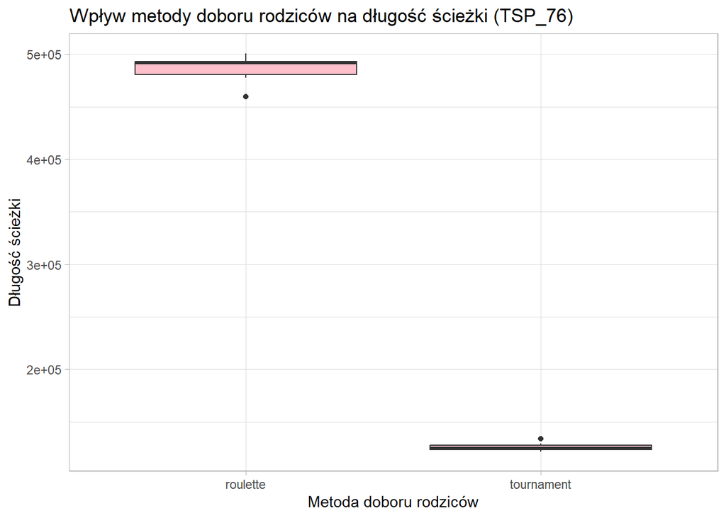

**Statystyki długości ścieżki w zależności od metody doboru rodziców (TSP_76)**

| PARAMETR | Min | Max | Mean |
| --- | --- | --- | --- |
| roulette | 459418.7 | 500868.9 | 486609.9 |
| tournament | 121744.9 | 134037.5 | 125958.3 |

Tutaj sytuacja analogiczna. Różnica pomiędzy wynikami jest diametralna.

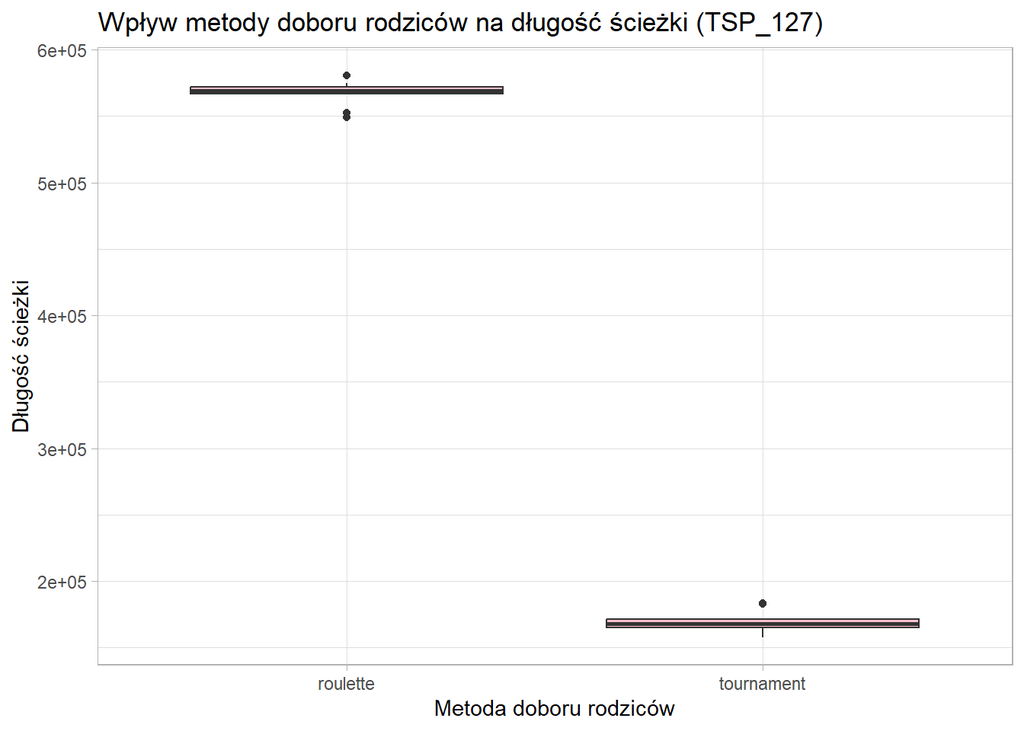

**Statystyki długości ścieżki w zależności od metody doboru rodziców (TSP_127)**

| PARAMETR | Min | Max | Mean |
| --- | --- | --- | --- |
| roulette | 549056.8 | 580734.4 | 567202.9 |
| tournament | 157986.9 | 183581.5 | 169827.2 |

Dla TSP_127 analogicznie.

Wyniki są definitywnie lepsze w przypadku metody doboru rodziców w sposób turniejowy. W ruletce wybór jest mocno losowy, co może prowadzić do selekcji słabszych osobników w wielu iteracjach. Natomiast metoda turniejowa z spośród losowo wybranych osobników, zawsze wybiera tego o najniższym koszcie, dlatego może działać lepiej.

### Metoda krzyżowania

Poniżej zbadany został wpływ metody krzyżowania na długość ścieżki:

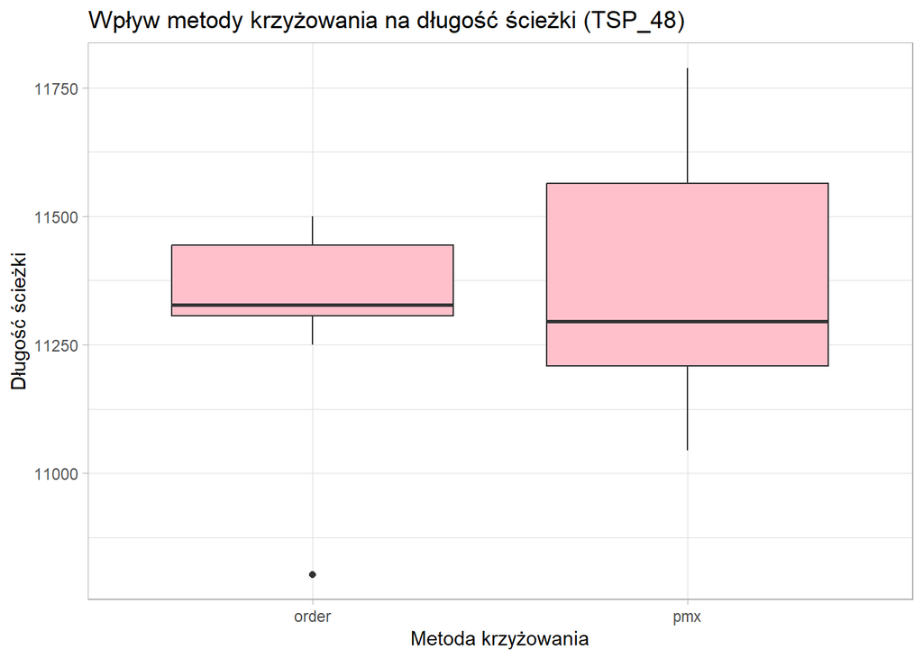

**Statystyki długości ścieżki w zależności od metody krzyżowania (TSP_48)**

| PARAMETR | Min | Max | Mean |
| --- | --- | --- | --- |
| order | 10803 | 11500 | 11316.1 |
| pmx | 11044 | 11789 | 11377.5 |

Średnia i mediana śa bardzo zbliżone do siebie. Żadna z metod się nie wyróżnia.

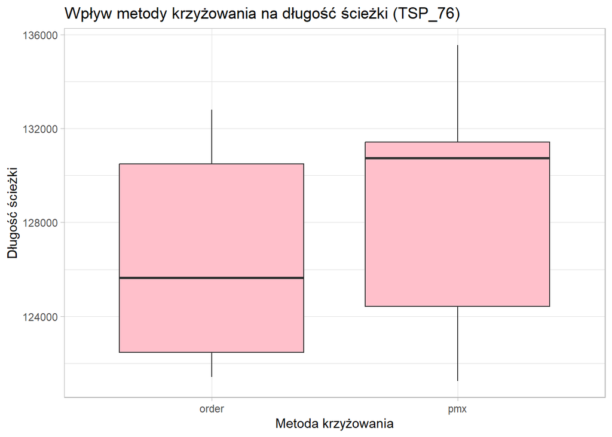

**Statystyki długości ścieżki w zależności od metody krzyżowania (TSP_76)**

| PARAMETR | Min | Max | Mean |
| --- | --- | --- | --- |
| order | 121416.9 | 132800.6 | 126438.4 |
| pmx | 121250.0 | 135554.5 | 128889.1 |

Dla TSP_76 mediana w przypadku metody `pmx` jest zdecydowanie wyższa. Średnie natomiast są zbliżone.

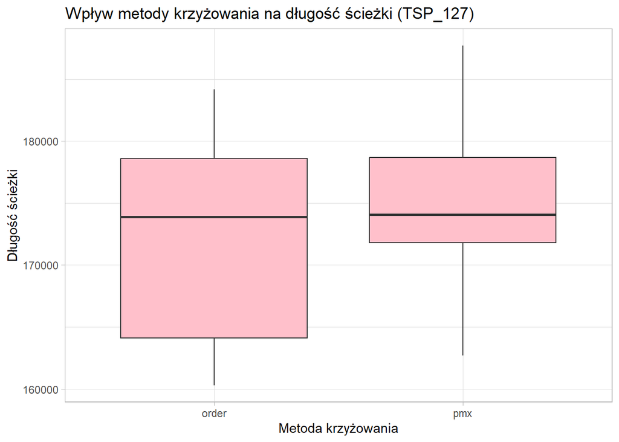

**Statystyki długości ścieżki w zależności od metody krzyżowania (TSP_127)**

| PARAMETR | Min | Max | Mean |
| --- | --- | --- | --- |
| order | 160299.3 | 184186.2 | 172502.4 |
| pmx | 162704.8 | 187712.2 | 174903.8 |

Dla TSP_127 zarówno mediana i średnia są do siebie zbliżone.

Nie widać więc tutaj żadnej zależności.

### Metoda mutacji

Poniżej zbadany został wpływ metody mutacji na długość ścieżki:

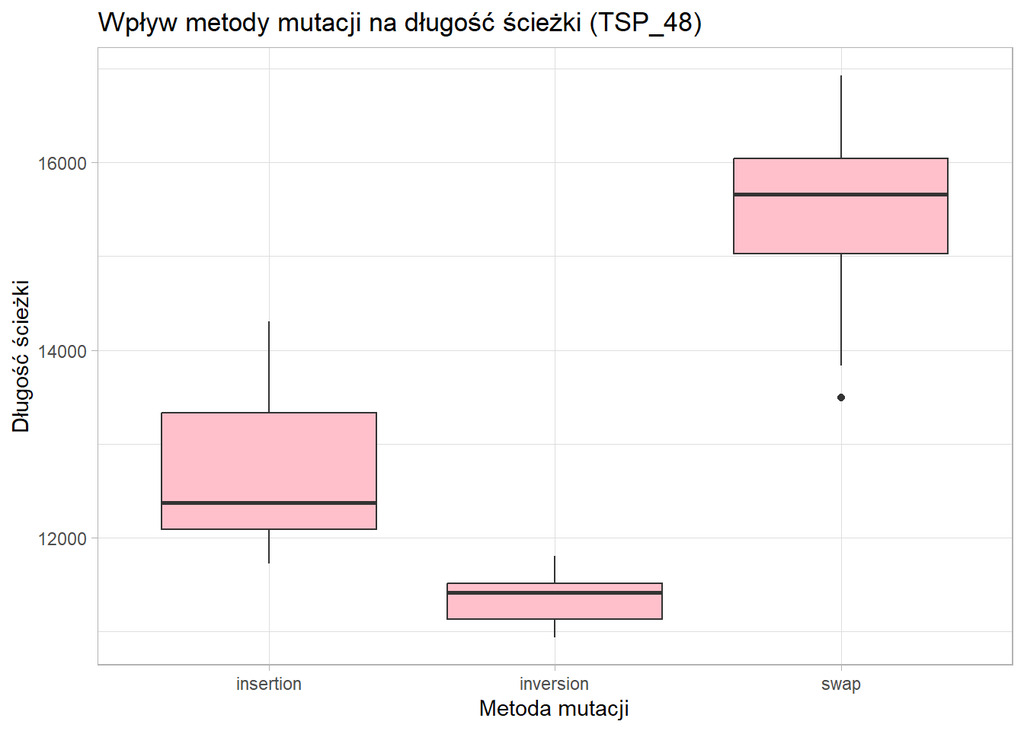

**Statystyki długości ścieżki w zależności od metody mutacji (TSP_48)**

| PARAMETR | Min | Max | Mean |
| --- | --- | --- | --- |
| insertion | 11722 | 14302 | 12706.1 |
| inversion | 10936 | 11804 | 11352.7 |
| swap | 13490 | 16933 | 15394.7 |

Dla TSP_48 najlepiej sprawdziła się metoda mutacji `inversion`. Natomiast najgorzej wypadła metoda `swap`. Metoda `insertion` nie ma dużo gorszych wyników.

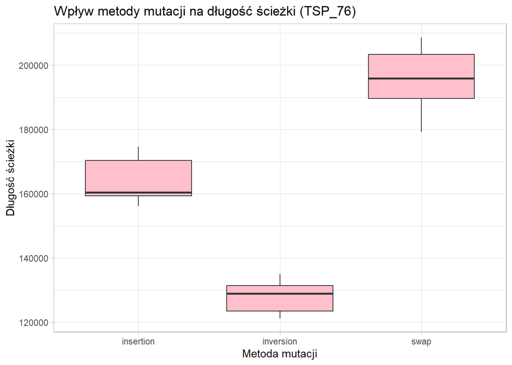

**Statystyki długości ścieżki w zależności od metody mutacji (TSP_76)**

| PARAMETR | Min | Max | Mean |
| --- | --- | --- | --- |
| insertion | 156134.6 | 174577.6 | 164110.3 |
| inversion | 121265.7 | 134879.8 | 127871.8 |
| swap | 179128.0 | 208574.2 | 195251.0 |

Tutaj pojawia się podobna sytuacja. Metoda `inversion` daje najlepsze wyniki. Jednak jest już większa różnica pomiędzy metodami.

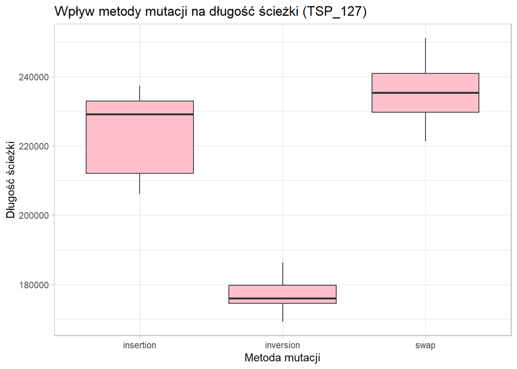

**Statystyki długości ścieżki w zależności od metody mutacji (TSP_127)**

| PARAMETR | Min | Max | Mean |
| --- | --- | --- | --- |
| insertion | 206135.3 | 237391.0 | 224001.9 |
| inversion | 169240.5 | 186296.1 | 176870.4 |
| swap | 221278.4 | 251153.6 | 235259.8 |

Dla TSP_127 analogiczna sytuacja.

Naefektywniejsza jest metoda `inversion` we wszystkich przypadkach. Najgorzej natomiast wypada `swap`.

## Podsumowanie

Najlepsze wyniki dla **TSP_48** przy zmianie poszczególnych parametrów:

- `Klasyczne` - 11048.0
- `Wielkość populacji` - 10795 (wielkość populacji - 15)
- `Prawdopodobieństwo mutacji` - 11055 (prawd. mutacja - 0.2)
- `Prawdopodobieństwo krzyżowania` - 10920 (prawd. krzyżowanie - 0.9)
- `Liczba pokoleń` - 10975 (liczba pokoleń - 10 tys.)
- `Metoda doboru rodziców` - 11173 (metoda - tournament)
- `Metoda krzyżowania` - 10803 (metoda - order)
- `Metoda mutacji` - 10936 (metoda - inversion)

Najlepsze wyniki dla **TSP_76** przy zmianie poszczególnych parametrów:

- `Klasyczne` - 116714.4
- `Wielkość populacji` - 112600.5 (wielkość populacji - 20)
- `Prawdopodobieństwo mutacji` - 115561.1 (prawd. mutacja - 0.2)
- `Prawdopodobieństwo krzyżowania` - 118452.6 (prawd. krzyżowanie - 0.8)
- `Liczba pokoleń` - 112672.9 (liczba pokoleń - 15 tys.)
- `Metoda doboru rodziców` - 121744.9 (metoda - tournament)
- `Metoda krzyżowania` - 121250.0 (metoda - pmx)
- `Metoda mutacji` - 121265.7 (metoda - inversion)

Dla TSP_76 przy użyciu algorytmu mrówkowego udało się uzyskać kilka lepszych wyników niż ten uzyskany przez Solver (118293.5).

Najlepsze wyniki dla **TSP_127** przy zmianie poszczególnych parametrów:

- `Klasyczne` - 165047.0
- `Wielkość populacji` - 141116.7 (wielkość populacji - 20)
- `Prawdopodobieństwo mutacji` - 162368.2 (prawd. mutacja - 0.2)
- `Prawdopodobieństwo krzyżowania` - 152547.3 (prawd. krzyżowanie - 0.7)
- `Liczba pokoleń` - 133161.4 (liczba pokoleń - 15.tys)
- `Metoda doboru rodziców` - 157986.9 (metoda - tournament)
- `Metoda krzyżowania` - 160299.3 (metoda - order)
- `Metoda mutacji` - 169240.5 (metoda - inversion)

Dla TSP_127 przy użyciu algorytmu mrówkowego udało się uzyskać lepszy wynik niż ten uzyskany przez Solver (140217.6).

# Algorytm mrówkowy (ACO)

*Algorytm mrówkowy* (ang. Ant Colony Optimization, ACO) został stworzony na podstawie obserwacji życia mrówek podczas szukania optymalnej drogi między mrowiskiem a źródłem pożywienia. Mrówki w środowisku naturalnym poruszają się losowo, ale zostawiają na swojej drodze feromony, które pomagają innym mrówkom znaleźć najkrótszą ścieżkę. Z czasem feromony parują (ich wpływ maleje), co pozwala wyeliminować nieoptymalne ścieżki. Algorytm ten dobrze sprawdza się w rozwiązywaniu problemu komiwojażera.

Zasada działania algorytmu do rozwiązania problemu komiwojażera wygląda następująco:

1. Połączenie między miastami inicjowane są niewielką ilością feromonu.
2. Każda mrówka umieszczana jest losowo w wybranym mieście, z którego przemieszcza się do kolejnego z prawdopodobieństwem P, będącym funkcją odległości do celu oraz wielkości śladu feromonowego pozostawionego na krawędzi łączącej je z tym miastem.
3. Mrówka poruszając się z miasta i do miasta j pozostawia za sobą ślad feromonowy odwrotnie proporcjonalny do długości trasy, którą przebyła .
4. Sztuczna mrówka wyposażona jest w pamięć w celu zapamiętania, które miasto już odwiedziła, aby uwzględnić je tylko jeden raz w swojej trasie (pamięć jest czyszczona przy rozpoczęciu każdego kolejnego cyklu przechodzenia).
5. Dla odwzorowania parowania feromonu występującego w naturze, w algorytmie feromon jest pomniejszany o określoną wartość po każdej iteracji, tak aby uniknąć zjawiska przedwczesnej zbieżności algorytmu.

## Badane parametry

- **`num_ants`** - liczba mrówek, która bierze udział w szukaniu optymalnej trasy. Jest ona zależna od liczby miast i wybierana z przedziału (0.5 * liczba miast, 2 * liczba miast)
- **`num_iterations`** - liczba iteracji
- **`alpha`** - parametr sterujący ważnością intensywności śladu feromonowego
- **`beta`** - parametr sterujący ważnością widoczności następnego miasta
- **`rho`** - prędkość odparowywania feromonu

### Klasyczne

Za podstawowe wartości parametrów przyjmujemy:

- num_ants = 10
- num_iterations = 100
- alpha = 1
- beta = 2
- rho = 0.5

| TSP_48 | TSP_76 | TSP_127 |
| --- | --- | --- |
| 12059 | 139982.4 | 137654.7 |
| 12365 | 136819.3 | 140743.3 |
| 12548 | 127968.1 | 141710.9 |
| 11621 | 126258.2 | 146917.2 |
| 12001 | 126208.8 | 136891.6 |
| 12017 | 128766.8 | 148829.9 |
| 11926 | 125386.1 | 136457.5 |
| 12216 | 135940.0 | 137785.2 |
| 11760 | 136243.6 | 134426.3 |
| 11540 | 124560.0 | 140478.7 |

|  | Min | Max | Mean |
| --- | --- | --- | --- |
| TSP_48 | 11540.0 | 12548.0 | 12005.3 |
| TSP_76 | 124560.0 | 139982.4 | 130813.3 |
| TSP_127 | 134426.3 | 148829.9 | 140189.5 |

W tabelce widzimy statystyki uzyskane dla podstawowych wartości parametrów dla algorytmu mrówkowego. Dla TSP_48 i TSP_76 wartości minimalne są wyższe niż uzyskane przez Solver. Jedynie dla TSP_127 otrzymany wynik jest lepszy. Natomiast średnie są dość podobne.

**Czas**

|  | Min | Max | Mean |
| --- | --- | --- | --- |
| TSP_48 | 1.934395 | 2.148533 | 1.984945 |
| TSP_76 | 4.548796 | 4.701536 | 4.622378 |
| TSP_127 | 12.354322 | 12.830323 | 12.615287 |

Średnie czasy trwania agorytmu są dość niskie. Jednak zwiększają się w zależności od liczby miast.

### Liczba mrówek

Poniżej zbadany został wpływ liczby mrówek na długość ścieżki:

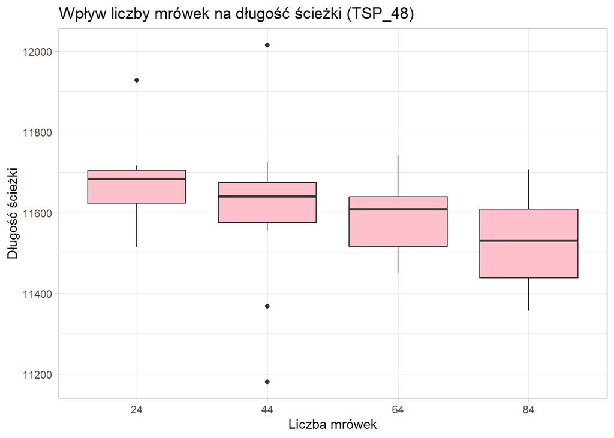

**Statystyki długości ścieżki w zależności od liczby mrówek (TSP_48)**

| PARAMETR | Min | Max | Mean |
| --- | --- | --- | --- |
| 24 | 11515 | 11927 | 11676.8 |
| 44 | 11181 | 12015 | 11609.7 |
| 64 | 11449 | 11741 | 11589.0 |
| 84 | 11357 | 11707 | 11530.2 |

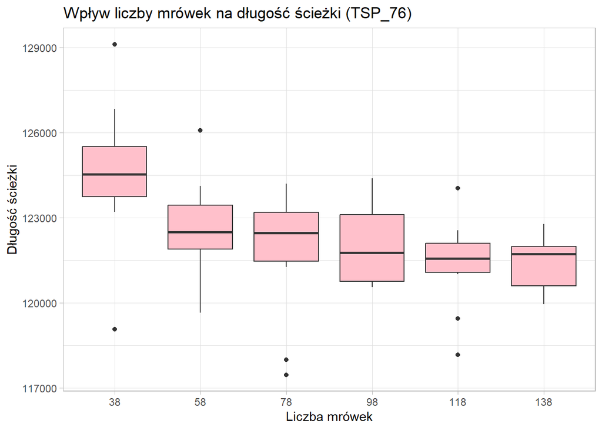

**Statystyki długości ścieżki w zależności od liczby mrówek (TSP_76)**

| PARAMETR | Min | Max | Mean |
| --- | --- | --- | --- |
| 38 | 119073.6 | 129111.1 | 124611.5 |
| 58 | 119658.2 | 126077.5 | 122690.4 |
| 78 | 117472.3 | 124202.6 | 121802.3 |
| 98 | 120562.6 | 124390.3 | 122025.8 |
| 118 | 118174.1 | 124043.6 | 121351.8 |
| 138 | 119955.0 | 122781.1 | 121427.1 |

Dla TSP_76 pojawia nam się podobna zależność. Mediana długości ścieżki widocznie się obniża i największe różnice widać na początku. Później te różnice nie są już takie znaczące. Uzyskane średnie dla wszystkich wartości parametrów są niższe niż średnia z Solvera (139999,45).

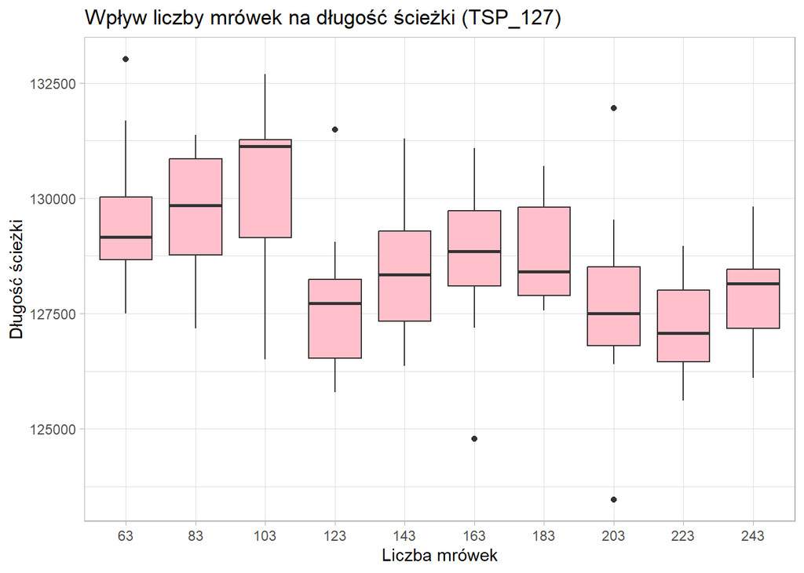

**Statystyki długości ścieżki w zależności od liczby mrówek (TSP_127)**

| PARAMETR | Min | Max | Mean |
| --- | --- | --- | --- |
| 63 | 127501.5 | 133017.3 | 129633.6 |
| 83 | 127173.8 | 131373.9 | 129615.6 |
| 103 | 126507.8 | 132685.1 | 130242.6 |
| 123 | 125798.8 | 131487.7 | 127802.8 |
| 143 | 126357.5 | 131285.8 | 128436.5 |
| 163 | 124786.8 | 131079.5 | 128706.4 |
| 183 | 127560.1 | 130692.6 | 128819.8 |
| 203 | 123471.0 | 131957.7 | 127664.9 |
| 223 | 125609.0 | 128963.1 | 127291.0 |
| 243 | 126097.7 | 129819.2 | 127924.4 |

Dla TSP_127 nie możemy już zobaczyć tej zależności, że mediana i średnia długości ścieżki maleje wraz ze wzrostem liczby mrówek. Widzimy tutaj, że raz rośnie, raz maleje. Średnia długość ścieżki co prawda zmalała od wartości parametru 123, jednak później wraz ze wzrostem jego wartości waha się i nie zmniejsza się znacząco.

W 2/3 przypadki wskazały, że wraz ze wzrostem liczby mrówek mediana i średnia długości ścieżki maleje. Warto też dodać, że średnie wyniki są lepsze w każdym z przypadków niż te otrzymane dla klasycznych wyników, gdzie liczba mrówek wynosiła 10.

### Liczba iteracji

Poniżej został zbadany wpływ liczby iteracji na długość ścieżki:

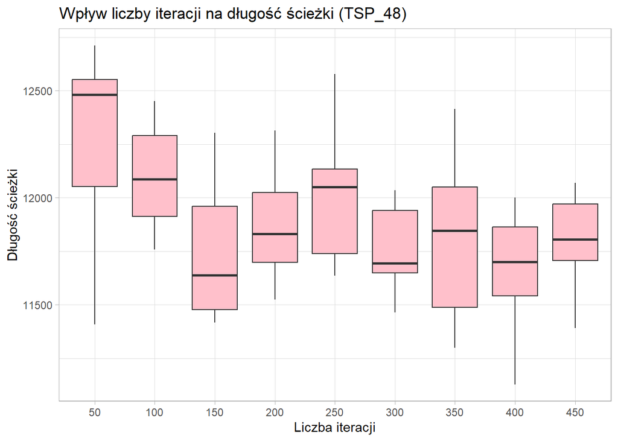

**Statystyki długości ścieżki w zależności od liczby iteracji (TSP_48)**

| PARAMETR | Min | Max | Mean |
| --- | --- | --- | --- |
| 50 | 11409 | 12712 | 12289.4 |
| 100 | 11759 | 12451 | 12098.7 |
| 150 | 11416 | 12304 | 11738.8 |
| 200 | 11524 | 12315 | 11870.3 |
| 250 | 11635 | 12579 | 12007.3 |
| 300 | 11465 | 12035 | 11752.1 |
| 350 | 11299 | 12416 | 11825.2 |
| 400 | 11128 | 12001 | 11675.5 |
| 450 | 11391 | 12069 | 11805.2 |

W przypadku zmian liczby iteracji, nie widać żadnej zależności. Mediana długości ścieżki raz rośnie, raz maleje. Jedyny duży spadek widać na początku. Dla parametrów powyżej wartości 100, mediany już są niższe, średnia również. Poza tym liczba iteracji nie wpływa znacząco na wyniki.

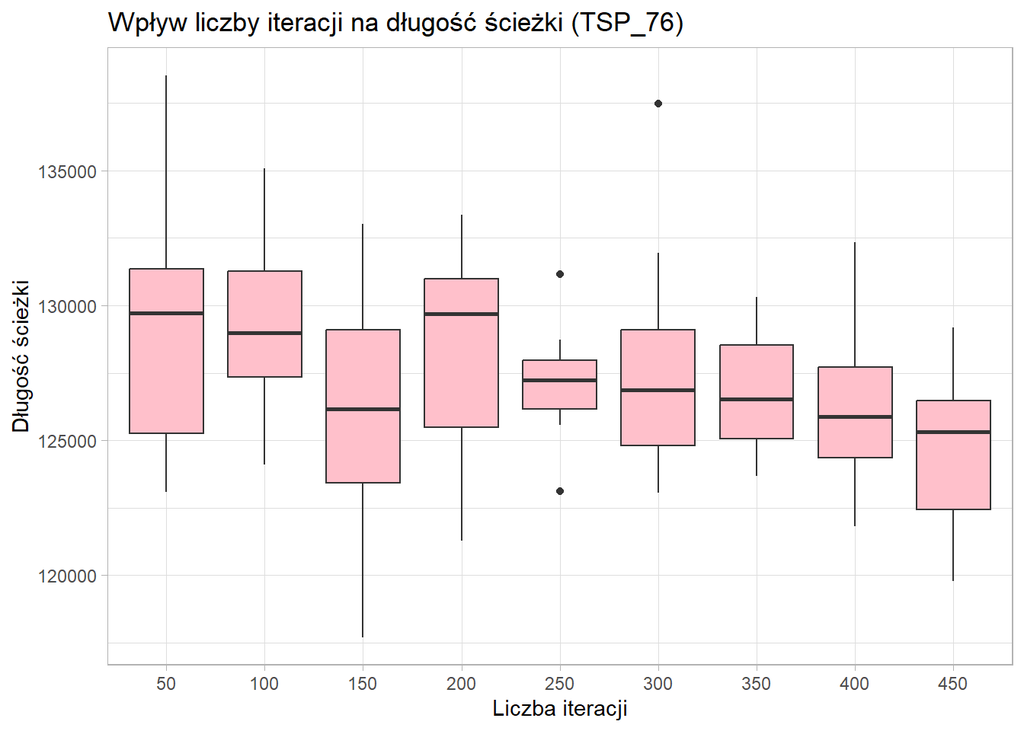

**Statystyki długości ścieżki w zależności od liczby iteracji (TSP_76)**

| PARAMETR | Min | Max | Mean |
| --- | --- | --- | --- |
| 50 | 123097.3 | 138528.5 | 129198.6 |
| 100 | 124099.2 | 135069.4 | 129283.1 |
| 150 | 117711.1 | 133019.9 | 126036.7 |
| 200 | 121284.4 | 133347.9 | 128311.9 |
| 250 | 123116.7 | 131142.8 | 127110.7 |
| 300 | 123065.4 | 137462.0 | 127878.2 |
| 350 | 123679.3 | 130312.6 | 126803.7 |
| 400 | 121821.0 | 132327.9 | 126169.2 |
| 450 | 119790.1 | 129186.9 | 124793.8 |

Dla TSP_76 pojawia się już bardziej widoczna zależność. Mediana i średnia długości ścieżki maleje wraz z liczbą iteracji. Jednak nie w bardzo znaczącym stopniu. Różnice są niewielkie. Pojawia się nam też jeden wyjątek od tej zależności dla liczby iteracji równej 150, gdzie mediana i średnia znacząco spadły. Otrzymane średnie sa niższe niż te otrzymane przez Solver.

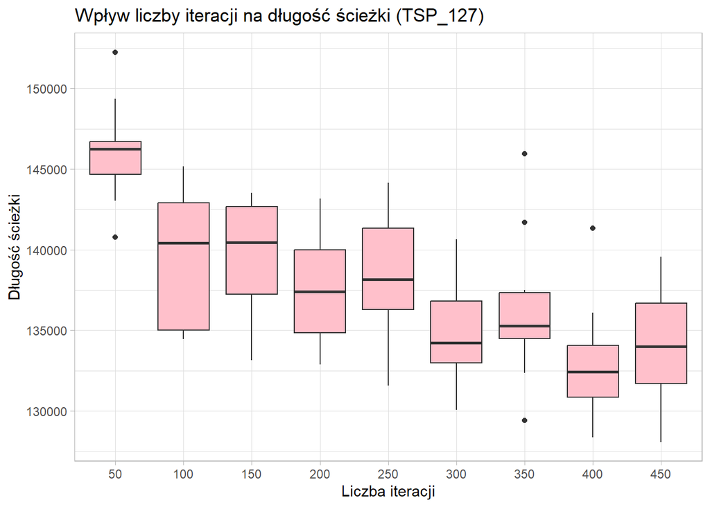

**Statystyki długości ścieżki w zależności od liczby iteracji (TSP_127)**

| PARAMETR | Min | Max | Mean |
| --- | --- | --- | --- |
| 50 | 140793.9 | 152253.7 | 146108.1 |
| 100 | 134444.7 | 145169.3 | 139548.8 |
| 150 | 133149.9 | 143513.2 | 139544.0 |
| 200 | 132898.3 | 143166.5 | 137609.7 |
| 250 | 131563.6 | 144157.2 | 138686.3 |
| 300 | 130082.2 | 140645.9 | 134915.1 |
| 350 | 129416.6 | 145938.2 | 136342.5 |
| 400 | 128376.8 | 141321.7 | 133009.6 |
| 450 | 128085.5 | 139558.8 | 134172.0 |

Dla TSP_127 spadek mediany i średniej wraz z wzrostem iteracji jest już bardziej widoczny. Jednak pojawiają się też pewne wahania. W odróżnieniu od poprzednich TSP, widać tutaj, że wraz z wzrostem iteracji maleje również minimalna wartość.

Wpływ liczby iteracji wydaje się być częściowo uzależniony od liczby miast. Gdy wynosiła ona 48 nie widać było zależności. Wraz z zwiększeniem liczby miast stawała się ona bardziej wyraźna. Jednak pojawiały się wtedy pewne wahania.

### Parametr alfa

Poniżej został zbadany wpływ parametru alfa na długość ścieżki:

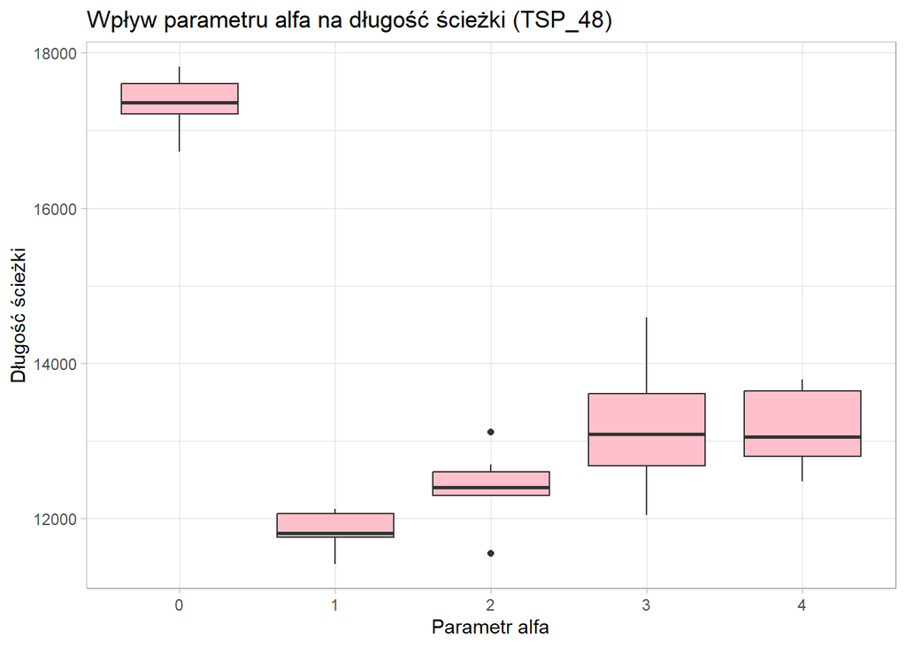

**Statystyki długości ścieżki w zależności od wartości parametru alfa (TSP_48)**

| PARAMETR | Min | Max | Mean |
| --- | --- | --- | --- |
| 0 | 16727 | 17823 | 17346.8 |
| 1 | 11414 | 12120 | 11860.1 |
| 2 | 11549 | 13111 | 12420.6 |
| 3 | 12046 | 14585 | 13173.6 |
| 4 | 12480 | 13793 | 13141.6 |

Dla wartości alpha równej 0 widać znaczną różnicę w medianie i średniej długości ścieżki w porównaniu do pozostałych wartości. Wynika to z faktu, że alpha odpowiada za wpływ intensywności śladu feromonowego na wybory mrówek. Gdy alpha wynosi 0, ślad feromonowy nie ma żadnego wpływu na ich decyzje. W rezultacie, pomimo istnienia informacji o jakości trasy (beta = 2), brak znaczenia intensywności feromonów sprawia, że mrówki nie są w stanie z niej skorzystać.

W przypadku alpha = 1, wyniki są najniższe. Jest to zapewne z wiązane z tym, że stosunek intensywności do widoczności feromonów jest najlepszy. Natomiast wraz ze wzrostem alpha, długość ścieżki rośnie, ponieważ gdy wartość alpha jest za duża w porównaniu do parametru beta, populacja mrówek traci różnorodność. Różnica mediany i średniej między alpha 3 i 4 jest znikoma. Różnica alphy w stosunku do bety jest na tyle wysoka, że zwiększanie alphy nie wpływa na poprawę, badź pogorszenie długości ścieżki.

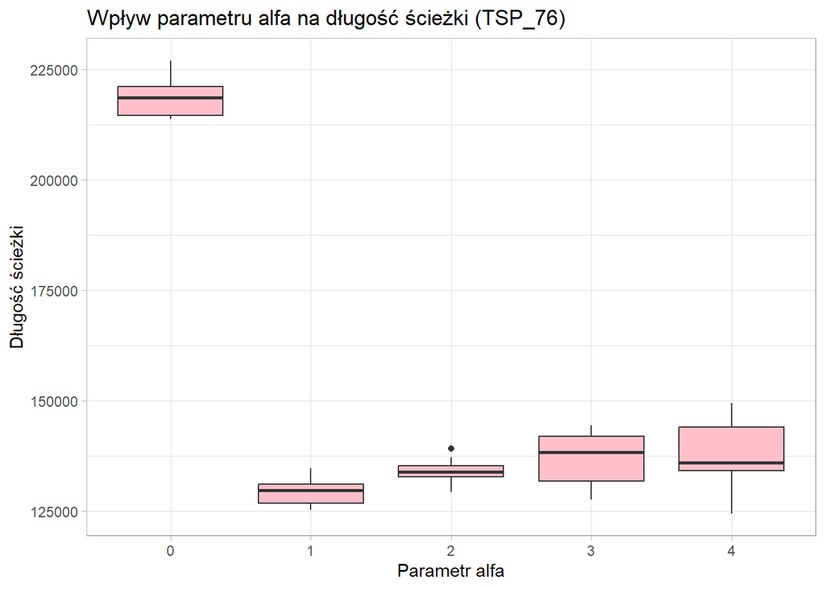

**Statystyki długości ścieżki w zależności od wartości parametru alfa (TSP_76)**

| PARAMETR | Min | Max | Mean |
| --- | --- | --- | --- |
| 0 | 213772.4 | 227005.4 | 218481.5 |
| 1 | 125278.5 | 134629.0 | 129432.6 |
| 2 | 129291.1 | 139081.9 | 133870.3 |
| 3 | 127596.1 | 144382.2 | 136928.3 |
| 4 | 124473.4 | 149482.6 | 137655.4 |

Tutaj sytuacja jest praktycznie identyczna. Dla alpha = 0 wyniki są najgorsze. Natomiast wraz ze wzrostem parametru (alpha > beta) wyniki pogarszają się do momentu gdzie nie ma już znaczącej różnicy w wynikach.

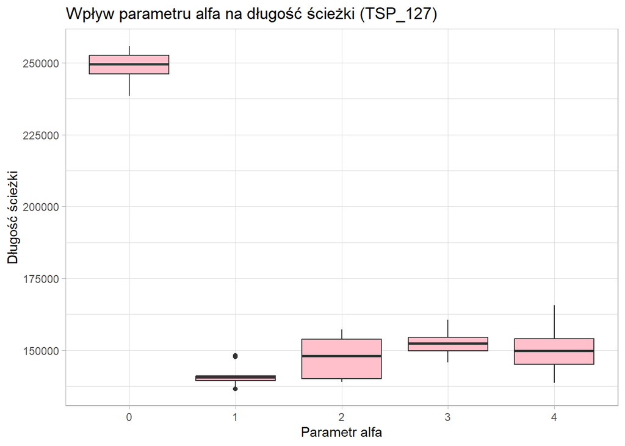

**Statystyki długości ścieżki w zależności od wartości parametru alfa (TSP_127)**

| PARAMETR | Min | Max | Mean |
| --- | --- | --- | --- |
| 0 | 238604.7 | 255907.2 | 248677.3 |
| 1 | 136597.7 | 148150.0 | 141137.4 |
| 2 | 138938.0 | 157241.6 | 147375.2 |
| 3 | 145721.5 | 160621.7 | 152597.1 |
| 4 | 138604.6 | 165688.1 | 149713.2 |

Dla TSP_127 analogiczna sytuacja.

Wartość parametru alpha istotnie wpływa na długość ścieżki, a tak naprawdę to jego różnica w stosunku do parametru beta. Gdy jest ona odpowiednia, wyniki są najlepsze (średnia i mediana długości ścieżki sa najniższe). W każdym przypadku najlepsze wyniki uzyskano dla alpha = 1 (beta = 2). Uzyskane wyniki nie są lepsze od tych uzyskanych za pomocą Solvera. Średnie są porównywalne bądź gorsze.

### Parametr beta

Poniżej został zbadany wpływ parametru beta na długość ścieżki:

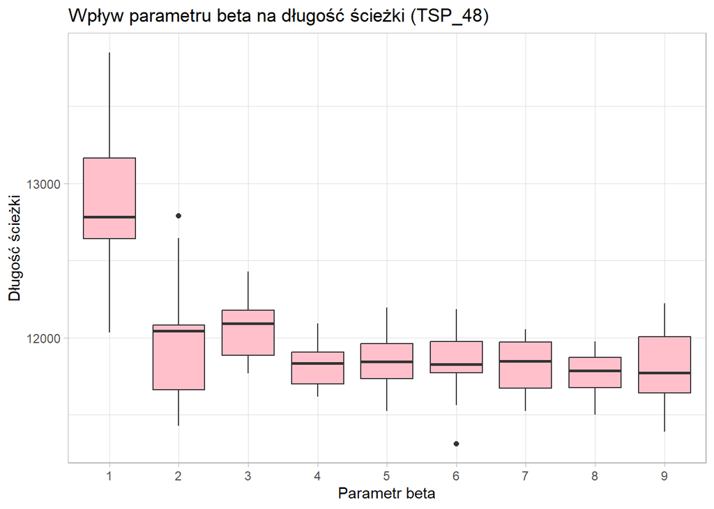

**Statystyki długości ścieżki w zależności od wartości parametru beta (TSP_48)**

| PARAMETR | Min | Max | Mean |
| --- | --- | --- | --- |
| 1 | 12034 | 13850 | 12870.5 |
| 2 | 11428 | 12790 | 12005.6 |
| 3 | 11768 | 12429 | 12051.1 |
| 4 | 11616 | 12093 | 11822.0 |
| 5 | 11525 | 12196 | 11841.6 |
| 6 | 11313 | 12184 | 11838.0 |
| 7 | 11525 | 12054 | 11810.9 |
| 8 | 11499 | 11974 | 11766.3 |
| 9 | 11392 | 12221 | 11789.4 |

Największa różnica w wynikach (długościach ścieżek) jest widoczna pomiędzy wartościami beta = 1 i beta = 2. Powodem tego jest fakt, że przy beta = 1 i alpha = 1 wpływ obu parametrów – feromonów (alpha) i heurystyki (beta) – jest równoważny. W takiej sytuacji różnica pomiędzy wpływem tych dwóch czynników jest zerowa, co prowadzi do najgorszych wyników. W przypadku bardziej zróżnicowanych wartości alpha i beta (np. beta = 2), jedna z tych strategii ma większy wpływ, co pozwala mrówkom na bardziej skoncentrowane działania i prowadzi do lepszych wyników. Natomiast gdy wartość bety wzrasta, tylko na początku widać delikatną poprawę w wynikach. Później median i średnia długości ścieżki już są bardzo podobne. Wyniki się nie poprawiają.

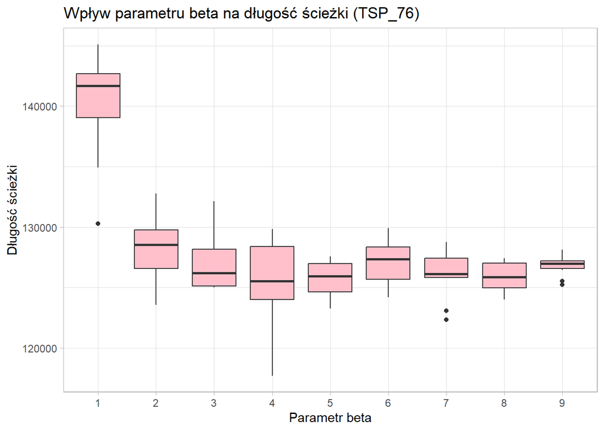

**Statystyki długości ścieżki w zależności od wartości parametru beta (TSP_76)**

| PARAMETR | Min | Max | Mean |
| --- | --- | --- | --- |
| 1 | 130268.4 | 145108.1 | 140320.1 |
| 2 | 123558.7 | 132768.7 | 128145.2 |
| 3 | 124994.8 | 132143.9 | 126965.8 |
| 4 | 117716.2 | 129832.3 | 125628.8 |
| 5 | 123264.9 | 127555.7 | 125765.2 |
| 6 | 124200.9 | 129917.3 | 127052.6 |
| 7 | 122348.1 | 128748.9 | 126078.6 |
| 8 | 124006.9 | 127417.5 | 125895.5 |
| 9 | 125222.0 | 128115.0 | 126831.5 |

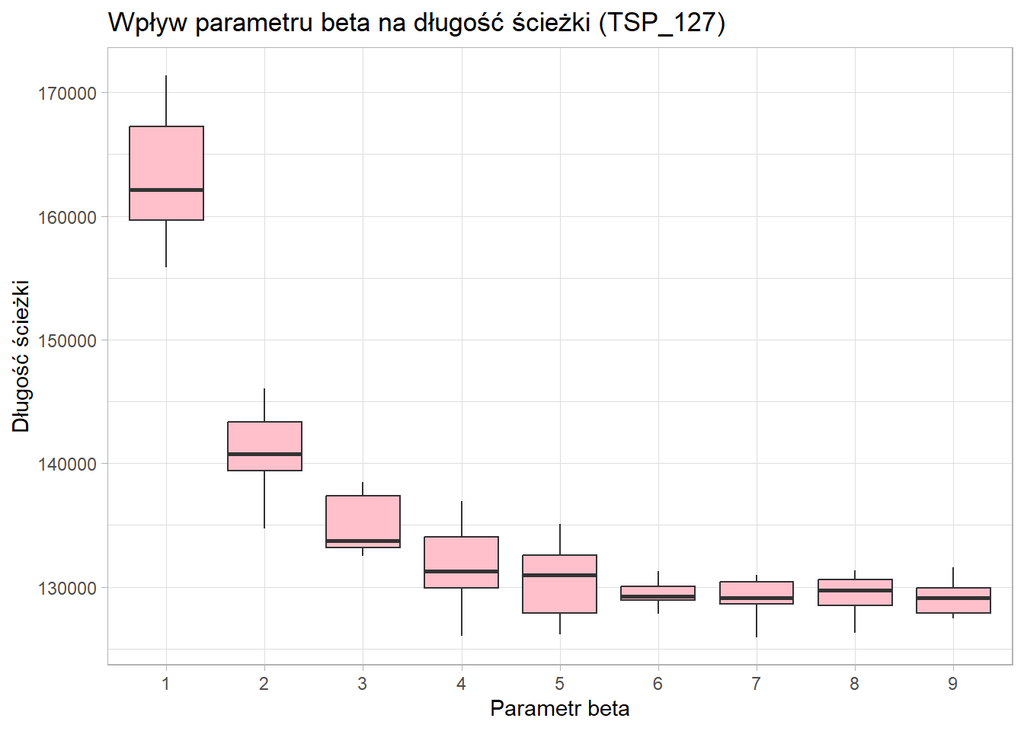

**Statystyki długości ścieżki w zależności od wartości parametru beta (TSP_127)**

| PARAMETR | Min | Max | Mean |
| --- | --- | --- | --- |
| 1 | 155858.3 | 171395.6 | 163212.9 |
| 2 | 134708.2 | 146036.3 | 140932.4 |
| 3 | 132490.1 | 138456.0 | 134933.7 |
| 4 | 126026.2 | 136904.3 | 131676.9 |
| 5 | 126128.5 | 135074.3 | 130478.8 |
| 6 | 127819.3 | 131279.8 | 129390.6 |
| 7 | 125936.3 | 130972.2 | 129060.0 |
| 8 | 126273.7 | 131341.1 | 129356.3 |
| 9 | 127438.4 | 131545.9 | 129084.2 |

Dla TSP_127 wzrost wartości parametru powoduje poprawę w wynikach. Średnia i mediana długości ścieżki maleją, aż do momentu gdzie już nie uzyskujemy poprawy i wyniki tylko nieznacznie wahają się wokół podobnej wartości. W tym przypadku wzrost wartości parametru beta spowodował największą poprawę.

Współczynnik beta znacząco wpływa na długość ścieżki. Jednak tak jak było wspomniane przy parametrze alpha, największe znaczenie ma różnica między tymi dwoma parametrami.

### Rho

Poniżej został zbadany wpływ rho na długość ścieżki:

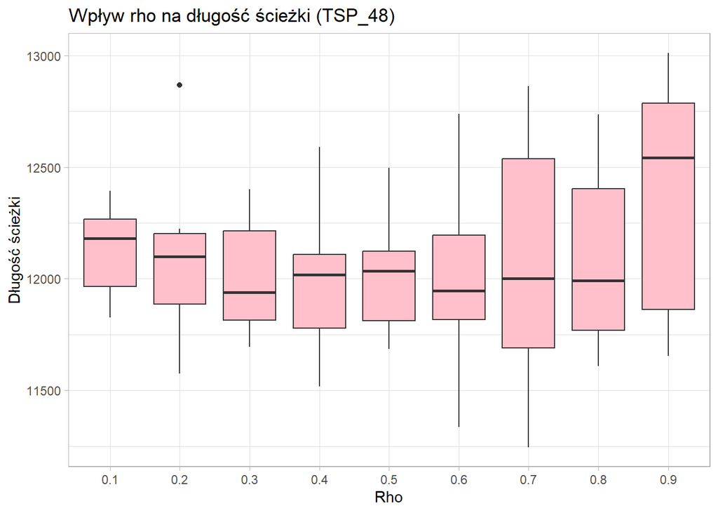

**Statystyki długości ścieżki w zależności od wartości rho (TSP_48)**

| PARAMETR | Min | Max | Mean |
| --- | --- | --- | --- |
| 0.1 | 11827 | 12394 | 12133.5 |
| 0.2 | 11575 | 12867 | 12081.4 |
| 0.3 | 11696 | 12401 | 12012.0 |
| 0.4 | 11518 | 12591 | 11978.1 |
| 0.5 | 11685 | 12496 | 12024.0 |
| 0.6 | 11337 | 12738 | 12009.0 |
| 0.7 | 11246 | 12863 | 12086.8 |
| 0.8 | 11608 | 12736 | 12091.3 |
| 0.9 | 11653 | 13012 | 12368.3 |

Wyniki średniej i mediany długości ścieżki wahają się wokół podobnych wartości niezależnie od wartości rho. Jedynie znacząca różnica jest dla rho = 0.9, średnia i mediana są zdecydowanie wyższe. Uzyskane średnie są zdecydowanie wyższe niż te otrzymane przez Solver.

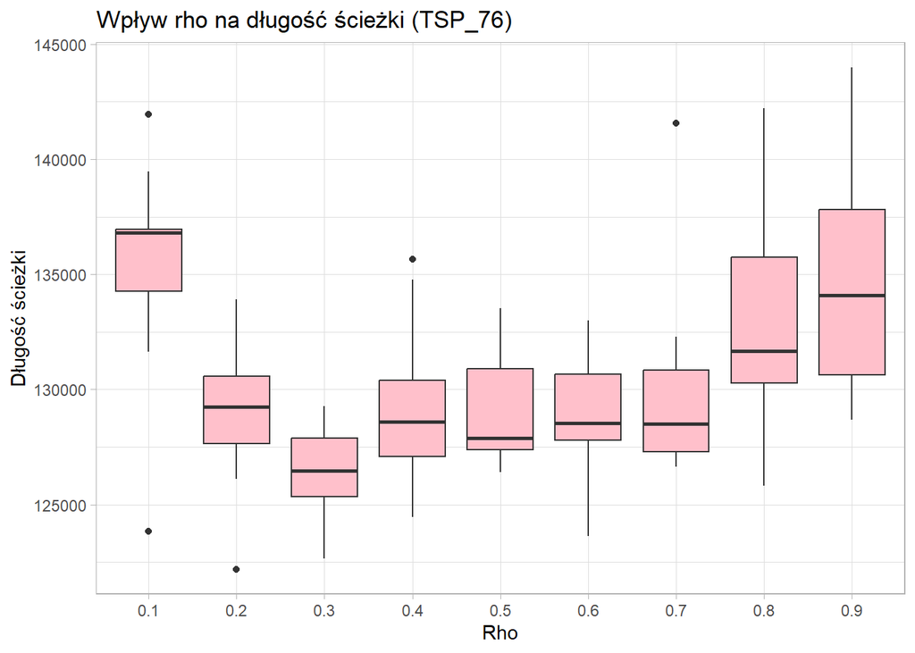

**Statystyki długości ścieżki w zależności od wartości rho (TSP_76)**

| PARAMETR | Min | Max | Mean |
| --- | --- | --- | --- |
| 0.1 | 123853.6 | 141959.3 | 135431.3 |
| 0.2 | 122202.6 | 133917.3 | 129006.2 |
| 0.3 | 122657.9 | 129284.1 | 126516.1 |
| 0.4 | 124467.7 | 135669.5 | 129337.7 |
| 0.5 | 126399.9 | 133526.4 | 129015.8 |
| 0.6 | 123622.4 | 133001.1 | 128848.4 |
| 0.7 | 126655.3 | 141571.2 | 130017.6 |
| 0.8 | 125830.8 | 142214.5 | 132965.4 |
| 0.9 | 128685.1 | 143994.4 | 134717.4 |

Dla TSP_76 widzimy natomiast, że różnice w średniej i medianie długości ścieżki są zdecydowanie największe w przypadku skrajnych wartości rho. Bardzo niskie wartości tego parametru oznaczają długotrwałe utrzymywanie się feromonów (bardzo wolne odparowywanie) co prowadzi do nadmiernej eksploatacji jednej trasy i ogranicza zdolność algorytmu do eksploracji nowych, potencjalnie lepszych tras. Natomiast zbyt wysokie wartości powodują bardzo szybkie odparowywanie feromonów co sprawia, że ślady na trasach szybko zanikają. W tej sytuacji algorytm prawie w ogóle nie korzysta z informacji zgromadzonych przez inne mrówki, ponieważ ślady feromonowe znikają zanim inne mrówki zdążą je wykorzystać. W związku z tym dla wartości rho, które oscylują wokół 0.5 wyniki są lepsze, ale jednocześnie zbliżone do siebie.

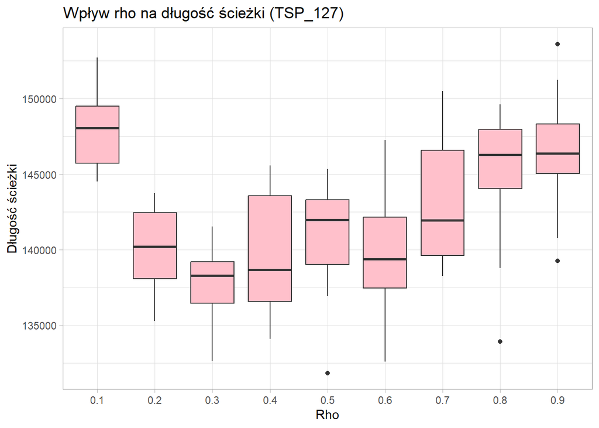

**Statystyki długości ścieżki w zależności od wartości rho (TSP_127)**

| PARAMETR | Min | Max | Mean |
| --- | --- | --- | --- |
| 0.1 | 144507.4 | 152725.6 | 148116.9 |
| 0.2 | 135261.7 | 143742.3 | 140050.9 |
| 0.3 | 132614.7 | 141534.9 | 137850.7 |
| 0.4 | 134080.5 | 145586.8 | 139601.9 |
| 0.5 | 131834.5 | 145328.7 | 140716.4 |
| 0.6 | 132574.6 | 147261.7 | 139715.6 |
| 0.7 | 138263.7 | 150503.5 | 143261.8 |
| 0.8 | 133920.8 | 149607.9 | 144824.1 |
| 0.9 | 139253.4 | 153615.6 | 146471.8 |

Najbardziej optymalne wyniki są uzyskiwane gdy rho przyjmuję wartości bliższe 0.5 niż skrajne (0.1 czy 0.9). Jednak wyniki nie są lepsze niż te uzyskane przez Solver. Jedynie w przypadku TSP_127 udało się otrzymać krótsze długości ścieżki.

## Podsumowanie

Najlepsze wyniki dla **TSP_48** przy zmianie poszczególnych parametrów:

- `Klasyczne` - 11540.0
- `Liczba mrówek` - 11181 (liczba mrówek - 44)
- `Liczba iteracji` - 11128 (liczba iteracji - 400)
- `Parametr alfa` - 11414 (alpha - 1)
- `Parametr beta` - 11313 (beta - 6)
- `Rho` - 11246 (rho - 0.7)

Dla TSP_48 przy użyciu algorytmu mrówkowego nie udało się uzyskać lepszego wyniku niż ten uzyskany przez Solver (10868).

Najlepsze wyniki dla **TSP_76** przy zmianie poszczególnych parametrów:

- `Klasyczne` - 124560.0
- `Liczba mrówek` - 117472.3 (liczba mrówek - 78)
- `Liczba iteracji` - 117711.1 (liczba iteracji - 150)
- `Parametr alfa` - 125278.5 (alpha - 1)
- `Parametr beta` - 117716.2 (beta - 4)
- `Rho` - 122202.6 (rho - 0.2)

Najlepsze wyniki dla **TSP_127** przy zmianie poszczególnych parametrów:

- `Klasyczne` - 134426.3
- `Liczba mrówek` - 123471.0 (liczba mrówek - 203)
- `Liczba iteracji` - 128085.5 (liczba iteracji - 450)
- `Parametr alfa` - 136597.7 (alpha - 1)
- `Parametr beta` - 125936.3 (beta - 7)
- `Rho` - 131834.5 (rho - 0.5)

Dla TSP_127 przy użyciu algorytmu mrówkowego udało się uzyskać lepsze wyniki niż ten uzyskany przez Solver (140217.6).

# Podsumowanie

W poniższych tabelach dokonano zestawienia najlepszych wyników uzyskanych dla każdego z analizowanych algorytmów.

**Porównanie najlepszych wyników dla poszczególnych algorytmów (TSP_48)**

| Algorytm | Najlepszy wynik |
| --- | --- |
| Iteracyjna wspinaczka | 10692 |
| Symulowane wyżarzanie | 10811 |
| Tabu Search | 10788 |
| Algorytmy Genetyczny | 10795 |
| Algorytm mrówkowy | 11128 |
| NN | 12012 |
| Solver | 10868 |

**Porównanie najlepszych wyników dla poszczególnych algorytmów (TSP_76)**

| Algorytm | Najlepszy wynik |
| --- | --- |
| Iteracyjna wspinaczka | 108942.2 |
| Symulowane wyżarzanie | 112768.6 |
| Tabu Search | 110041.2 |
| Algorytmy Genetyczny | 112600.5 |
| Algorytm mrówkowy | 117472.3 |
| NN | 130921.0 |
| Solver | 118293.5 |

**Porównanie najlepszych wyników dla poszczególnych algorytmów (TSP_127)**

| Algorytm | Najlepszy wynik |
| --- | --- |
| Iteracyjna wspinaczka | 119118.3 |
| Symulowane wyżarzanie | 143162.3 |
| Tabu Search | 120791.7 |
| Algorytmy Genetyczny | 133161.4 |
| Algorytm mrówkowy | 123471.0 |
| NN | 133970.6 |
| Solver | 140217.6 |

Porównując wyniki uzyskane przy zastosowaniu poszczególnych algorytmów w kontekście problemu komiwojażera można zauważyć, że dla każdego z trzech przypadków (TSP_48, TSP_76 oraz TSP_127) osiągane wyniki w przeważającej większości były niższe od wartości uzyskanych za pomocą Solvera. Gorsze rezultaty uzyskano jedynie dla algorytmu mrówkowego i NN w przypadku TSP_48, dla algorytmu NN w przypadku TSP_76 oraz dla algorytmu symulowanego wyżarzania w przypadku TSP_127.

Dla wszystkich trzech przypadków najlepsze rezultaty spośród wszystkich rozważanych algorytmów uzyskano za pomocą algorytmu iteracyjnej wspinaczki. Wspomniany algorytm wykazał się największą skutecznością w kontekście minimalizacji długości trasy. Na drugim miejscu pod względem uzyskanych wyników znalazł się algorytm Tabu Search, którego wyniki również w każdym analizowanym przypadków były lepsze od rezultatów Sovera. Również algorytm genetyczny zwrócił lepsze wyniki w odniesieniu do tych z Solvera. Pozostałe algorytmy osiągały gorsze rezultaty.